# 第4章实验｜从概率预测到三种分类方法

先用 UCI 信用卡数据观察单特征线性模型，再理解 Logistic 回归、kNN 和朴素贝叶斯；随后用月牙数据比较边界形状。指标与阈值选择属于第5讲预习，放在末尾附录。

核心计算放在前面。结果图紧跟对应解释，绘图实现和可选实验集中在末尾；课堂可跳过绘图细节。数据来源与离线准备见数据卡。

```python
# 显示辅助：放大Notebook正文、表格和print输出；运行本格即可应用，不影响计算。
from IPython.display import HTML, display
display(HTML("""<style id="course-notebook-readability">
.jp-RenderedMarkdown, .text_cell_render {font-size:20px!important;line-height:1.7!important;}
.jp-RenderedMarkdown p, .jp-RenderedMarkdown li, .jp-RenderedMarkdown blockquote,
.text_cell_render p, .text_cell_render li, .text_cell_render blockquote {font-size:20px!important;line-height:1.7!important;}
.jp-RenderedHTMLCommon table, .rendered_html table {font-size:20px!important;line-height:1.6;}
.jp-RenderedHTMLCommon table th, .jp-RenderedHTMLCommon table td,
.rendered_html table th, .rendered_html table td {font-size:20px!important;padding:12px 14px!important;line-height:1.6!important;}
.jp-RenderedHTMLCommon table th, .rendered_html table th {font-weight:600;}
@media(max-width:700px){.jp-RenderedHTMLCommon table th,.jp-RenderedHTMLCommon table td{padding:8px!important;}}
@media print{.jp-RenderedHTMLCommon table th,.jp-RenderedHTMLCommon table td,
.rendered_html table th,.rendered_html table td{font-size:13pt!important;padding:6px 8px!important;}}
.jp-RenderedText pre, .output_text pre, .output_stream pre {font-size:20px!important;line-height:1.6!important;font-family:var(--jp-code-font-family,monospace)!important;}
@media print{.jp-RenderedText pre,.output_text pre,.output_stream pre{font-size:13pt!important;}}
</style>"""))
```

## 课件与 Notebook 对照

| 当前课件 | 对应内容 |
| --- | --- |
| p1—p3：任务、UCI 数据、单特征线性模型 | 第1—3节；模型输出绘图 |
| p4—p8：odds、logit、sigmoid、阈值 | 第4—5节；函数图，tanh 详解在附录 |
| p9—p13：损失与最大似然 | 四样本似然计算；损失曲线、梯度与数值核对在绘图附录之后 |
| p14—p16：kNN 投票、成本、k 的影响 | UCI 投票与成本；第9节 k=1/3/15 对照及绘图 |
| p17—p18：朴素贝叶斯与平滑 | 从计数到分类、拉普拉斯加一 |
| p19—p20：历史故事 | 课件阅读背景，不安排训练实验 |
| p21—p24：判别/生成、GAN/LLM、多分类预告 | 第8节展示生成式分类，第9节比较模型；GAN/LLM/OvR 是课件拓展，不在本 Notebook 训练 |
| p25—p29：读边界、同分、错例、小结与作业 | 第5节验证集前五条、第9节月牙比较、UCI三模型结果、本讲检查题 |

**口径**：UCI 的模型只在训练集拟合；月牙是另一份合成数据。课件插画中的蓝/红投票和零概率示意，不是 UCI 的实际输出。第5讲指标与阈值预习放在末尾附录。

## 1｜准确率80%可能什么都没做到吗？

本数据中违约约占 22.1%。先只看类别比例，再用全猜未违约建立基线。

**数据准备（辅助代码，不是训练算法）**：下格依次识别 CSV、已有 XLS 或 ZIP；都没有时从 UCI 自动下载并转换，缓存到本章 `notebook/data/`。转换旧版 XLS 的 xlrd 已列入课程依赖，独立运行时若缺失会自动安装。自动下载使用 UCI 官方较小的 CSV，并转换成课程的两行表头；仍用 `header=1` 读取，样本顺序和八个特征不变。来源、许可及离线说明见 data/README.md。

```python
# 数据准备辅助代码：先复用 CSV，再转换已有 XLS/ZIP，最后才联网。
from pathlib import Path
from urllib.request import Request, urlopen
import hashlib
import shutil
import zipfile
import numpy as np
import pandas as pd
import matplotlib.pyplot as plt
from matplotlib_inline.backend_inline import set_matplotlib_formats
set_matplotlib_formats("retina")  # 内嵌图使用双倍像素，显示尺寸不变
plt.rcParams.update({"figure.dpi": 120, "savefig.dpi": 240})

cwd = Path.cwd()
notebook_dir = next((p for p in [cwd, cwd / "lessons/04-classification-probability/notebook"]
                     if (p / "04-classification-probability.ipynb").exists()), cwd)
asset_dir = notebook_dir.parent / "assets" if notebook_dir.name == "notebook" else notebook_dir / "assets"
asset_dir.mkdir(parents=True, exist_ok=True)
data_dirs = [notebook_dir / "data", cwd / "data",
             notebook_dir.parent.parent / "04-classification-probability/notebook/data",
             cwd / "lessons/04-classification-probability/notebook/data"]
csv_name = "default of credit card clients.csv"
xls_name = "default of credit card clients.xls"
data_path = next((p / csv_name for p in data_dirs if (p / csv_name).exists()), None)
if data_path is None:
    cache_dir = notebook_dir / "data"
    cache_dir.mkdir(parents=True, exist_ok=True)
    xls_path = next((p / xls_name for p in data_dirs if (p / xls_name).exists()), None)
    zip_names = ["default-credit-card-clients.zip", "default+of+credit+card+clients.zip"]
    zip_path = next((p / name for p in data_dirs for name in zip_names
                     if (p / name).exists()), None)
    if xls_path is None and zip_path is not None:
        xls_path = cache_dir / xls_name
        # 只取指定数据文件，不执行下载内容，也不解压其他路径。
        with zipfile.ZipFile(zip_path) as archive:
            with archive.open(xls_name) as source, xls_path.open("wb") as out:
                shutil.copyfileobj(source, out)
    if xls_path is not None:
        # xlrd 仅用于旧版 .xls；独立上传 Notebook 时也自动补齐。
        import importlib.util, subprocess, sys
        if importlib.util.find_spec("xlrd") is None:
            print("转换 XLS：安装 xlrd==2.0.2 到当前内核……", flush=True)
            subprocess.run([sys.executable, "-m", "pip", "install", "xlrd==2.0.2"], check=True)
        raw = pd.read_excel(xls_path, header=None, engine="xlrd")
    else:
        # UCI 官方 API 指向这个较小的 CSV，避免下载 5.3 MB 的 XLS。
        source_path = next((p / name for p in data_dirs for name in ["uci350-source.csv", "data.csv"]
                            if (p / name).exists()), cache_dir / "uci350-source.csv")
        if not source_path.exists():
            url = "https://archive.ics.uci.edu/static/public/350/data.csv"
            partial = source_path.with_suffix(".csv.partial")
            print("首次准备：从 UCI 自动下载信用卡数据（约 2.8 MB）……", flush=True)
            try:
                with urlopen(Request(url, headers={"User-Agent": "ML-course-notebook"}), timeout=60) as response, partial.open("wb") as out:
                    shutil.copyfileobj(response, out)
                if hashlib.sha256(partial.read_bytes()).hexdigest() != "45bcf4df62ff2e237a74eb155cabfb4bbbc171219a0637daef44fdad07503dd0":
                    raise ValueError("UCI 文件校验不一致，请联系教师核查来源版本。")
                partial.replace(source_path)
            except Exception as exc:
                partial.unlink(missing_ok=True)
                raise RuntimeError("自动下载未完成，请检查网络后重跑本格；已有 CSV/XLS/ZIP 会自动复用。") from exc
        official = pd.read_csv(source_path)
        # 检查官方原始表的行数和列数。
        assert official.shape == (30000, 25)
        original_names = ["", *[f"X{i}" for i in range(1, 24)], "Y"]
        standard_names = ["ID", "LIMIT_BAL", "SEX", "EDUCATION", "MARRIAGE", "AGE",
                          "PAY_0", "PAY_2", "PAY_3", "PAY_4", "PAY_5", "PAY_6",
                          *[f"BILL_AMT{i}" for i in range(1, 7)],
                          *[f"PAY_AMT{i}" for i in range(1, 7)], "default payment next month"]
        # 检查表头与官方数据格式一致。
        assert list(official.columns) == ["ID", *original_names[1:]]
        # 转换成课程的两行表头；不排序、不删样本、不改数值。
        raw = pd.concat([pd.DataFrame([original_names, standard_names]),
                         pd.DataFrame(official.to_numpy())], ignore_index=True)
    data_path = cache_dir / csv_name
    partial_csv = data_path.with_suffix(".csv.partial")
    raw.to_csv(partial_csv, index=False, header=False, encoding="utf-8")
    converted = pd.read_csv(partial_csv, header=1, index_col=0)
    if converted.shape != (30000, 24) or "default payment next month" not in converted:
        partial_csv.unlink(missing_ok=True)
        raise ValueError("数据形状或表头不符合 UCI 350，请联系教师核查。")
    partial_csv.replace(data_path)
    print("已自动转换并缓存 CSV；下次无需联网。")
else:
    print("复用已有 CSV：", data_path)

credit = pd.read_csv(data_path, header=1, index_col=0)
feature_names = [
    "LIMIT_BAL", "PAY_0", "PAY_2", "PAY_3",
    "BILL_AMT1", "BILL_AMT2", "PAY_AMT1", "PAY_AMT2",
]
# 检查数据完整，且客户ID没有重复。
assert credit.shape == (30000, 24) and credit.index.is_unique
# 检查本次使用的特征没有缺失值。
assert credit[feature_names].notna().all().all()
# 核对当前UCI数据版本的两类人数。
assert credit["default payment next month"].value_counts().to_dict() == {0: 23364, 1: 6636}
X_cls = credit[feature_names].copy()
y_cls = credit["default payment next month"].astype(int)
print("数据来源：UCI 信用卡违约数据（2005年），CC BY 4.0")
print("特征与标签形状:", X_cls.shape, y_cls.shape)
print("类别计数（未违约 0、违约 1）:", np.bincount(y_cls))
```

```
Matplotlib is building the font cache; this may take a moment.
```

```
复用已有 CSV： /Users/momo/Documents/workspace/教学/2026机器学习与概率统计-本科/lessons/04-classification-probability/notebook/data/default of credit card clients.csv
数据来源：UCI 信用卡违约数据（2005年），CC BY 4.0
特征与标签形状: (30000, 8) (30000,)
类别计数（未违约 0、违约 1）: [23364  6636]
```

本章使用 UCI「信用卡客户违约」真实数据（2005年）。每行是一名客户，标签记录其下个月是否违约。原数据有 30,000 行和 23 个特征；本实验选取 8 个额度、还款状态、账单金额与还款金额特征，不使用客户编号和人口属性。数据只用于教学复现实验，不代表当前信贷决策表现。

已有数据可离线运行；缺失时由上方代码自动下载并转换，之后复用本地缓存。来源、引用与 CC BY 4.0 许可见本目录 `data/README.md`。

**停一下，检查：** 如果把所有客户都预测为 0，正类召回率是多少？

**查看解释**

0。多数类准确率约为 78%，仍会漏掉全部违约客户。

## 2｜哪些数据可以用来作决定？

保留训练、验证、测试三份。先检查大小，暂时不查看测试表现。

```python
from sklearn.model_selection import train_test_split
X_dev, X_final, y_dev, y_final = train_test_split(
    X_cls, y_cls, test_size=0.2, stratify=y_cls, random_state=42)
X_fit, X_valid, y_fit, y_valid = train_test_split(
    X_dev, y_dev, test_size=0.25, stratify=y_dev, random_state=42)
print("训练、验证、测试:", len(y_fit), len(y_valid), len(y_final))
```

```
训练、验证、测试: 18000 6000 6000
```

得到训练 18,000、验证 6,000、测试 6,000。分层抽样尽量保持各份数据中的违约比例。最终测试集只在方案冻结后使用。

## 3｜用一个特征做分类，会发生什么？

只输入信用额度 `LIMIT_BAL`，沿用刚才的训练/验证划分，不调整类别比例。先训练、再预测和评价，最后画出课件 p3 的对照图。

### 先看额度有没有区分信息

对应 p3 的描述性统计：把全体客户的信用额度分成五组，比较违约比例。这不是模型训练或测试成绩，也不用该表选择阈值。

```python
credit_amount_bins = pd.qcut(X_cls["LIMIT_BAL"], q=5, duplicates="drop")
credit_amount_summary = y_cls.groupby(credit_amount_bins, observed=True).agg(["size", "mean"])
credit_amount_summary.columns = ["客户数", "违约率"]
display(credit_amount_summary.style.format({"违约率": "{:.1%}"}))
```

| LIMIT_BAL | 客户数 | 违约率 |
| --- | --- | --- |
| (9999.999, 50000.0] | 7676 | 31.8% |
| (50000.0, 100000.0] | 4822 | 25.8% |
| (100000.0, 180000.0] | 6123 | 19.9% |
| (180000.0, 270000.0] | 5421 | 16.9% |
| (270000.0, 1000000.0] | 5958 | 13.8% |

### 3.1｜取出一个特征

两种模型使用完全相同的数据。标准化（standardization）会在下一步的流水线（Pipeline）中仅根据训练集拟合。

```python
from sklearn.linear_model import LinearRegression
from sklearn.pipeline import make_pipeline
from sklearn.preprocessing import StandardScaler
from sklearn.svm import LinearSVC


# 双重方括号保留二维表：每行一个客户，此处只有一列特征。
demo_feature = "LIMIT_BAL"
demo_train = X_fit[[demo_feature]]
demo_valid = X_valid[[demo_feature]]
print("训练 / 验证形状：", demo_train.shape, demo_valid.shape)
display(demo_train.head())
```

```
训练 / 验证形状： (18000, 1) (6000, 1)
```

| ID | LIMIT_BAL |
| --- | --- |
| 10575 | 20000 |
| 11331 | 300000 |
| 7128 | 500000 |
| 25151 | 70000 |
| 6001 | 50000 |

### 3.2｜训练两个线性模型

`LinearRegression` 原本预测连续数值；`LinearSVC` 直接用于分类。先分别建立模型，再用 `fit` 学习参数。

Pipeline（流水线）把标准化和模型串起来：训练时先学习标准化参数，再训练模型；预测时沿用训练时的标准化规则，不重新学习。

下方表格只确认模型结构、训练状态和输入特征数；“已训练”不代表预测准确。下一格查看实际预测，再用验证集评价效果。

```python
linear_regression = make_pipeline(StandardScaler(), LinearRegression())
linear_svc = make_pipeline(StandardScaler(), LinearSVC(C=1.0, dual=False, max_iter=5000, random_state=42))
linear_regression.fit(demo_train, y_fit)
linear_svc.fit(demo_train, y_fit)

# 训练完成后给出简洁反馈；预测和评价放在后面的单元格。
display(pd.DataFrame({
    "模型": ["线性回归", "线性 SVC"],
    "处理流程": ["标准化 → 线性回归", "标准化 → 线性分类"],
    "状态": ["已训练", "已训练"],
    "输入特征数": [linear_regression.n_features_in_, linear_svc.n_features_in_],
}))
```

|  | 模型 | 处理流程 | 状态 | 输入特征数 |
| --- | --- | --- | --- | --- |
| 0 | 线性回归 | 标准化 → 线性回归 | 已训练 | 1 |
| 1 | 线性 SVC | 标准化 → 线性分类 | 已训练 | 1 |

### 3.3｜预测：连续输出与类别不同

回归输出不保证落在 0–1，因此不能直接当作概率；这里人为用 0.5 转成类别。SVC 的 `predict` 直接返回 0 或 1。

```python
regression_output = linear_regression.predict(demo_valid)
regression_class = (regression_output >= .5).astype(int)
svc_class = linear_svc.predict(demo_valid)
y_true = y_valid.to_numpy()

display(pd.DataFrame({"真实标签": y_true[:5], "回归输出": regression_output[:5], "回归预测类别": regression_class[:5], "SVC预测类别": svc_class[:5]}))
```

|  | 真实标签 | 回归输出 | 回归预测类别 | SVC预测类别 |
| --- | --- | --- | --- | --- |
| 0 | 1 | 0.298967 | 0 | 0 |
| 1 | 0 | 0.130155 | 0 | 0 |
| 2 | 1 | 0.204010 | 0 | 0 |
| 3 | 0 | 0.182909 | 0 | 0 |
| 4 | 0 | 0.204010 | 0 | 0 |

### 3.4｜和“全猜未违约”比较

错误率（error rate）是判错人数占比；召回率（recall）是实际违约客户中被找回的比例。`y_true == 1` 只选出实际违约客户。

```python
regression_error = np.mean(regression_class != y_true)
svc_error = np.mean(svc_class != y_true)
regression_recall = np.mean(regression_class[y_true == 1] == 1)
svc_recall = np.mean(svc_class[y_true == 1] == 1)
baseline_error = np.mean(y_true == 1)
outside = np.sum((regression_output < 0) | (regression_output > 1))
print(f"LinearRegression：错误率 {regression_error:.2%}；违约召回率 {regression_recall:.2%}")
print(f"LinearSVC：错误率 {svc_error:.2%}；违约召回率 {svc_recall:.2%}")
print(f"全猜 0 错误率 {baseline_error:.2%}；LinearRegression 输出范围 [{regression_output.min():.3f}, {regression_output.max():.3f}]，越界 {outside} 个")
```

```
LinearRegression：错误率 22.12%；违约召回率 0.00%
LinearSVC：错误率 22.12%；违约召回率 0.00%
全猜 0 错误率 22.12%；LinearRegression 输出范围 [-0.218, 0.304]，越界 25 个
```

### 观察两个模型的输出

[figure not shown]

结果图保留在这里；可编辑的绘图代码集中在末尾附录。图片由该代码生成，完整重跑后会更新。

**读结果：**两个模型的错误率均约 22.12%，违约召回率均为 0，与全猜未违约相同。回归输出存在越界；SVC 在这些验证样本上都预测为未违约；分界点的计算放在末尾附录。

**停一下：**错误率不高，为什么仍没有找回违约客户？单个额度特征和当前配置不足以把两类分开；不能由此断言所有线性分类器都无效。接下来用八个特征建立概率模型。

## 4｜从概率到 Logistic 回归：odds → logit → sigmoid

二分类中，令 p=P(Y=1) 表示正类发生的概率。几率（odds）比较发生与不发生：odds=p/(1−p)，反过来 p=odds/(1+odds)。

| 事件 | p | 1−p | odds |
| --- | --- | --- | --- |
| 抛硬币为正面 | 0.5 | 0.5 | 1 |
| 掷骰子出 6 | 1/6 | 5/6 | 0.2 |
| 下雨（假设） | 0.8 | 0.2 | 4 |
| 中奖（假设） | 0.01 | 0.99 | 约 0.0101 |

例如 p=0.5 时 odds=1；p=0.75 时 odds=3。注意 odds ratio（优势比/几率比）是两个 odds 的比，不是单个 odds。

对 odds 取自然对数，得到对数几率（log-odds），也叫 logit：logit(p)=ln[p/(1−p)]，取值范围是整个实数轴。Logistic 回归令条件概率 p(x)=P(Y=1|x) 满足 logit(p(x))=wᵀx+b=z；反解便得到 p(x)=1/[1+exp(−z)]，也就是 Logistic sigmoid。模型对概率的 log-odds 建模，不是直接对 0/1 标签做普通线性回归。

现在训练一个模型：先将缩放和 Logistic 回归放进 Pipeline。

```python
from sklearn.linear_model import LogisticRegression
from sklearn.pipeline import make_pipeline
from sklearn.preprocessing import StandardScaler
logistic = make_pipeline(
    StandardScaler(), LogisticRegression(max_iter=1000, random_state=42))
logistic.fit(X_fit, y_fit)
print("学到的系数形状:", logistic[-1].coef_.shape)
```

```
学到的系数形状: (1, 8)
```

缩放器仅在X_fit拟合。系数形状(1,8)：这里是二分类的一组8维权重，另有截距。

**停一下，检查：** 对验证集进行预测时，标准化会改用验证集的均值和标准差吗？

**查看解释**

不会；Pipeline 沿用训练集上拟合的均值和标准差，只做变换，不重新拟合。

### sigmoid 与阶跃的区别

[figure not shown]

结果图保留在这里；可编辑的绘图代码集中在末尾附录。图片由该代码生成，完整重跑后会更新。

## 5｜概率怎样变成类别？

`predict_proba(X_valid)` 为每个验证样本输出两列概率：本例类别顺序是 `[0, 1]`，第一列为未违约概率，第二列为违约概率，两列相加为 1。

`[:, 1]` 中的 `:` 表示保留所有样本，`1` 表示取第二列（Python 从 0 编号）。因此 `valid_proba` 是每个验证样本的**预测违约概率**，不是预测标签。下表展示前五个概率，并用变量 `decision_threshold` 指定阈值（默认 0.5）来给出类别。

```python
# 先看每个样本的两列概率，再取类别 1 的概率。
all_proba = logistic.predict_proba(X_valid)
print("概率列对应的类别：", logistic.classes_)
print("概率矩阵形状：", all_proba.shape)
display(pd.DataFrame(all_proba[:5], columns=["P(未违约=0)", "P(违约=1)"]))
valid_proba = all_proba[:, 1]
print("取第二列后的前五个概率：", valid_proba[:5].round(4))
print("第一行两列相加：", all_proba[0].sum())
```

```
概率列对应的类别： [0 1]
概率矩阵形状： (6000, 2)
```

|  | P(未违约=0) | P(违约=1) |
| --- | --- | --- |
| 0 | 0.752733 | 0.247267 |
| 1 | 0.861040 | 0.138960 |
| 2 | 0.946411 | 0.053589 |
| 3 | 0.899656 | 0.100344 |
| 4 | 0.907804 | 0.092196 |

```
取第二列后的前五个概率： [0.2473 0.139  0.0536 0.1003 0.0922]
第一行两列相加： 1.0
```

```python
decision_threshold = 0.5  # 当前分类阈值，可调整
valid_proba = logistic.predict_proba(X_valid)[:, 1]
pred_valid = (valid_proba >= decision_threshold).astype(int)
display(pd.DataFrame({
    "p(default)": valid_proba[:5],
    f"prediction@{decision_threshold:g}": np.where(pred_valid[:5] == 1, "default", "no default"),
    "actual": np.where(y_valid.iloc[:5].to_numpy() == 1, "default", "no default"),
}))
```

|  | p(default) | prediction@0.5 | actual |
| --- | --- | --- | --- |
| 0 | 0.247267 | no default | default |
| 1 | 0.138960 | no default | no default |
| 2 | 0.053589 | no default | default |
| 3 | 0.100344 | no default | no default |
| 4 | 0.092196 | no default | no default |

本次运行前五个 `valid_proba` 约为 `[0.2473, 0.1390, 0.0536, 0.1003, 0.0922]`，与上表逐行对应。第一个样本的预测违约概率约为 **24.7%**，未违约概率约为 **75.3%**；使用默认阈值 0.5 时预测为未违约，但它的真实标签是违约，说明概率预测也会出错。

这里的 24.7% 不是模型准确率，也不是确定的结果。阈值是把概率转为类别的决策规则；改阈值不需要重新 `fit`。概率估计也不自动等于已校准的概率。概率列的顺序由 `logistic.classes_` 决定，本例是 `[0, 1]`。[sklearn 文档](https://scikit-learn.org/stable/modules/generated/sklearn.linear_model.LogisticRegression.html#sklearn.linear_model.LogisticRegression.predict_proba)

**停一下，检查：** 0.49与0.51的样本很相近，为什么类别不同？

**查看解释**

0.5阈值把连续分数离散化；类别边界由规则决定。

## 6｜交叉熵与似然：用四个样本核对

模型输出正类概率 $p_i=P(Y=1\mid x_i;\theta)$。真实标签为 1 时真类概率 $q_i=p_i$，为 0 时 $q_i=1-p_i$。

条件独立样本的**似然（likelihood）** $L(\theta)$ 是模型对已观察到这组标签给出的联合条件概率；它是参数 $\theta$ 的函数，不是“参数为真的概率”。

$$L(\theta)=\prod_i q_i,\qquad -\frac1N\ln L(\theta)=-\frac1N\sum_i\ln q_i.$$

下面沿用课件四样本例子。最大化似然等价于最小化平均交叉熵（这里不含正则项）。

```python
likelihood_labels = np.array([1, 0, 1, 0])
likelihood_predictions = {"A": np.array([0.9, 0.1, 0.8, 0.2]),
                          "B": np.array([0.6, 0.4, 0.6, 0.4])}
for name, probabilities in likelihood_predictions.items():
    true_class_prob = np.where(likelihood_labels == 1, probabilities, 1 - probabilities)
    likelihood = true_class_prob.prod()
    mean_cross_entropy = -np.log(true_class_prob).mean()
    print(name, "真类概率:", true_class_prob.round(2),
          "似然 L:", round(likelihood, 4), "平均交叉熵:", round(mean_cross_entropy, 4))
```

```
A 真类概率: [0.9 0.9 0.8 0.8] 似然 L: 0.5184 平均交叉熵: 0.1643
B 真类概率: [0.6 0.6 0.6 0.6] 似然 L: 0.1296 平均交叉熵: 0.5108
```

A 的似然为 0.5184，B 为 0.1296；A 对这组真实标签给出的联合概率更高，平均交叉熵也更低。它只说明对这四个样本的拟合，不说明泛化性能。

sklearn 的 Logistic 回归默认还带正则化，因此实际训练不只是裸的最大似然。长推导选读：[Stanford CS229：Logistic regression](https://cs229.stanford.edu/notes2022fall/main_notes.pdf)。

## 7｜UCI 信用卡数据：kNN 的投票与计算成本

对应课件 kNN 原理与计算成本页。沿用 UCI **Default of Credit Card Clients**：30,000 名客户，本实验使用 8 个特征，训练/验证/测试为 18,000/6,000/6,000。以下只用训练和验证数据。

目标：看见三个近邻如何投票；区分准备、查询和存储成本。索引测速放在可选附录。

kNN 属于**懒惰学习（lazy learning）**，保存样本，预测时再搜索。相对的 **急切学习（eager learning）** 先从训练数据拟合模型，再用模型预测，如 Logistic 回归。两者都有计算成本，主要花在不同阶段。

### 7.1｜只在训练集拟合标准化，再保存训练样本

固定 k=3、欧氏距离、均匀投票和暴力搜索，不在本节调参。

```python
# [ref:knn-uci-cost]
from sklearn.preprocessing import StandardScaler
from sklearn.neighbors import KNeighborsClassifier

knn_scaler = StandardScaler()
knn_train = knn_scaler.fit_transform(X_fit)
knn_valid = knn_scaler.transform(X_valid)
knn_credit = KNeighborsClassifier(n_neighbors=3, algorithm="brute", n_jobs=1)
knn_credit.fit(knn_train, y_fit)
# 核对训练集为18,000个样本、8个特征。
assert knn_train.shape == (18000, 8)
print("UCI 训练样本 × 特征:", knn_train.shape)
print("保存的训练样本数:", knn_credit.n_samples_fit_)
```

```
UCI 训练样本 × 特征: (18000, 8)
保存的训练样本数: 18000
```

没有梯度下降更新分类权重，但 `fit` 仍检查和保存数据；标准化还学习了均值与方差。下面查的是一个**验证客户**，不是训练样本本人。

### 7.2｜查看最近三个训练客户

```python
knn_query = knn_valid[:1]
knn_distances, knn_indices = knn_credit.kneighbors(knn_query)
knn_positions = knn_indices[0]
knn_neighbor_labels = y_fit.iloc[knn_positions].to_numpy()
display(pd.DataFrame({
    "训练客户ID": X_fit.index[knn_positions],
    "标准化后的欧氏距离": knn_distances[0].round(4),
    "真实标签（1=违约）": knn_neighbor_labels,
}))
print("查询客户ID:", X_valid.index[0], "真实标签:", int(y_valid.iloc[0]))
```

|  | 训练客户ID | 标准化后的欧氏距离 | 真实标签（1=违约） |
| --- | --- | --- | --- |
| 0 | 6550 | 0.0035 | 0 |
| 1 | 21278 | 0.0059 | 0 |
| 2 | 14791 | 0.0102 | 0 |

```
查询客户ID: 18317 真实标签: 1
```

返回的索引是训练数组中的行位置，因此用 `iloc` 取标签；距离同时使用了 8 个标准化特征，不是只比较额度。

### 7.3｜手算投票，并与模型核对

```python
knn_vote_probability = knn_neighbor_labels.mean()
knn_model_probability = knn_credit.predict_proba(knn_query)[0, 1]
knn_vote_class = int(knn_neighbor_labels.sum() >= 2)
# 检查手算投票概率与模型输出近似相等。
assert np.isclose(knn_vote_probability, knn_model_probability)
# 检查手算多数票与模型预测一致。
assert knn_vote_class == int(knn_credit.predict(knn_query)[0])
print("三个邻居的标签:", knn_neighbor_labels.tolist())
print("P(违约) = 违约邻居数/3 =", round(knn_vote_probability, 4))
print("预测标签:", knn_vote_class)
```

```
三个邻居的标签: [0, 0, 0]
P(违约) = 违约邻居数/3 = 0.0
预测标签: 0
```

本例采用均匀投票，所以概率就是近邻中违约样本的比例；它不自动等于校准好的风险概率。一个客户预测正确或错误，也不能判断模型整体效果。

### 7.4｜不只看一个客户：初步分类结果

用已拟合的8特征 kNN，对同一批6,000名验证客户预测。先看前五条，再看整体准确率与违约召回率；仍用当前默认阈值，不在这里选择 k 或调整阈值。数据和标准化都沿用前面的训练/验证划分。

```python
from threadpoolctl import threadpool_limits
with threadpool_limits(limits=1):
    knn_credit_proba = knn_credit.predict_proba(knn_valid)[:, 1]
knn_credit_pred = (knn_credit_proba >= decision_threshold).astype(int)
display(pd.DataFrame({"客户ID": X_valid.index[:5],
                      "kNN违约概率": knn_credit_proba[:5], "预测标签": knn_credit_pred[:5],
                      "真实标签": y_valid.iloc[:5].to_numpy()}))
```

|  | 客户ID | kNN违约概率 | 预测标签 | 真实标签 |
| --- | --- | --- | --- | --- |
| 0 | 18317 | 0.000000 | 0 | 1 |
| 1 | 1483 | 0.000000 | 0 | 0 |
| 2 | 10397 | 0.666667 | 1 | 1 |
| 3 | 9361 | 0.333333 | 0 | 0 |
| 4 | 18145 | 0.666667 | 1 | 0 |

准确率（Accuracy）是答对人数除以总人数；违约召回率（Recall）是找回的违约客户数除以实际违约人数。

$$\mathrm{Accuracy}=\frac{\text{预测正确人数}}{\text{总人数}},\qquad \mathrm{Recall}=\frac{\text{实际违约且预测违约人数}}{\text{实际违约人数}}.$$

```python
knn_actual = y_valid.to_numpy()
knn_accuracy = (knn_credit_pred == knn_actual).mean()
knn_recall = ((knn_credit_pred == 1) & (knn_actual == 1)).sum() / (knn_actual == 1).sum()
print(f"kNN验证准确率 Accuracy：{knn_accuracy:.2%}")
print(f"违约召回率 Recall：{knn_recall:.2%}")
print("预测为违约的人数:", int((knn_credit_pred == 1).sum()), "/", len(knn_actual))
```

```
kNN验证准确率 Accuracy：77.67%
违约召回率 Recall：36.62%
预测为违约的人数: 985 / 6000
```

### 7.5｜先算计算量，不把估算当实测耗时

暴力搜索对每个查询遍历所有训练样本。距离次数是 m×n，每次距离涉及 d 个特征；下面的 n×d×8 仅是 float64 特征数组的字节数，不含标签、索引和临时工作内存。

```python
knn_sizes = [1000, 3000, 6000, 18000]
knn_queries = knn_valid[:200]
knn_dimension = knn_train.shape[1]
knn_work = pd.DataFrame({
    "训练样本数 n": knn_sizes,
    "每次查询的距离次数": knn_sizes,
    "200次查询的距离次数": np.array(knn_sizes) * len(knn_queries),
    "特征数组 KiB（不含其他开销）":
        np.array(knn_sizes) * knn_dimension * knn_train.itemsize / 1024,
})
display(knn_work)
```

|  | 训练样本数 n | 每次查询的距离次数 | 200次查询的距离次数 | 特征数组 KiB（不含其他开销） |
| --- | --- | --- | --- | --- |
| 0 | 1000 | 1000 | 200000 | 62.5 |
| 1 | 3000 | 3000 | 600000 | 187.5 |
| 2 | 6000 | 6000 | 1200000 | 375.0 |
| 3 | 18000 | 18000 | 3600000 | 1125.0 |

n=18,000 时，单次查询对应 18,000 次八维距离；200 次查询对应 3,600,000 次八维距离。不是 18,000 次浮点运算。

**复杂度（complexity）**：设训练样本数为 $n$、特征数为 $d$、查询数为 $m$。

| 阶段 | 暴力搜索的成本 | 含义 |
| --- | --- | --- |
| 准备与存储 | 数据读取/复制 $O(nd)$；存储 $O(nd)$ | 不迭代拟合分类权重，但不是零成本 |
| 单次预测 | 距离计算 $O(nd)$ | 线性选择近邻并投票时，整体仍为 $O(nd)$ |
| $m$ 次预测 | $O(mnd)$ | 把主要计算推迟到查询时 |

全排序还需 $O(n\log n)$，但找最近 $k$ 个不必全排序。KD-Tree、Ball-Tree 可减少距离计算；低维、小 $k$ 时常有效，实际收益还取决于数据结构和查询量，没有统一的对数查询保证。

**想一想**：每天预测十万名新客户，能否仅凭“kNN 训练快”选择它？减小 $k$ 能否消除暴力查询的主要成本？

**参考解释**

还要比较查询延迟、吞吐量、内存和更新频率。减小 $k$ 不会消除遍历全部样本的距离计算；二分类 Logistic 回归拟合后，单次线性得分和 sigmoid 通常只需 $O(d)$，不计共同预处理。搜索方法的实测对照见末尾附录。

来源：[sklearn：近邻算法选择](https://scikit-learn.org/stable/modules/neighbors.html#choice-of-nearest-neighbors-algorithm)。更完整的选择因素和计时实验见附录。

## 8｜朴素贝叶斯：从计数到分类，再处理零概率

继续使用 **UCI 信用卡违约数据与已有的18,000条训练记录**。只取两个原始离散特征，方便逐项计算：`PAY_0` 是2005年9月还款状态，`PAY_3` 是7月还款状态。标签仍是下个月是否违约。

**朴素贝叶斯（Naive Bayes）**学习先验 $P(Y=y)$ 和类条件分布 $P(X_j\mid Y=y)$。假设给定类别后各特征条件独立，分别计算两类得分，再取最大的类别：

$$s_y=P(Y=y)\prod_j P(X_j=x_j\mid Y=y),\qquad P(Y=y\mid X=x)=\frac{s_y}{\sum_c s_c}.$$

这里将还款状态编码当作**类别**，不当连续距离，不做标准化。编码1表示延迟一个月；负值与0保留原编码，不擅自合并或解释为同一种状态。两个特征可能相关，“朴素”假设是简化，不保证完全真实。

### 8.1｜查看原始训练记录

```python
bayes_features = ["PAY_0", "PAY_3"]
bayes_train = X_fit[bayes_features].astype(int)
bayes_categories = {feature: np.sort(bayes_train[feature].unique()) for feature in bayes_features}
display(bayes_train.head().join(y_fit.rename("下个月是否违约")))
print("用于拟合的训练记录数:", len(bayes_train))
print("训练集中各特征的类别表:", {f: values.tolist() for f, values in bayes_categories.items()})
```

| ID | PAY_0 | PAY_3 | 下个月是否违约 |
| --- | --- | --- | --- |
| 10575 | 0 | 0 | 0 |
| 11331 | 0 | 0 | 0 |
| 7128 | -1 | -1 | 0 |
| 25151 | 0 | 0 | 0 |
| 6001 | 0 | 0 | 0 |

```
用于拟合的训练记录数: 18000
训练集中各特征的类别表: {'PAY_0': [-2, -1, 0, 1, 2, 3, 4, 5, 6, 7, 8], 'PAY_3': [-2, -1, 0, 1, 2, 3, 4, 5, 6, 7, 8]}
```

### 8.2｜从训练标签学习先验

先验就是两类在训练集中的比例。这里不是人为设成各占一半：未违约14,018人、违约3,982人，先验约为77.88%与22.12%。

```python
bayes_class_counts = y_fit.value_counts().sort_index()
bayes_priors = bayes_class_counts / len(y_fit)
display(pd.DataFrame({"训练人数": bayes_class_counts, "先验 P(Y)": bayes_priors})
        .rename_axis("类别：0未违约，1违约"))
# 核对当前固定划分的两类训练人数。
assert bayes_class_counts.to_dict() == {0: 14018, 1: 3982}
```

| 类别：0未违约，1违约 | 训练人数 | 先验 P(Y) |
| --- | --- | --- |
| 0 | 14018 | 0.778778 |
| 1 | 3982 | 0.221222 |

#### 8.2.1｜分别统计每类中各还款状态出现多少次

先看计数表，再除以该类总人数：$P(X_j=v\mid Y=y)=N_{jyv}/N_y$。这就是本例的拟合过程，不需要梯度下降；统计只来自训练集。

注意 `PAY_3=1` 这一行：未违约类有2条，违约类为0条。“这个组合没见过”不等于它不可能发生。

```python
bayes_counts = {feature: pd.crosstab(bayes_train[feature], y_fit)
               .reindex(index=bayes_categories[feature], columns=[0, 1], fill_value=0)
               for feature in bayes_features}
for feature, counts in bayes_counts.items():
    print(feature, "训练计数：两列分别为未违约(0)、违约(1)")
    display(counts)
    # 检查各取值的计数合计等于该类人数。
    assert np.array_equal(counts.sum(axis=0).to_numpy(), bayes_class_counts.to_numpy())
# 核对该取值在两类中的计数为2和0。
assert bayes_counts["PAY_3"].loc[1].tolist() == [2, 0]
```

```
PAY_0 训练计数：两列分别为未违约(0)、违约(1)
```

| default payment next month PAY_0 | 0 | 1 |
| --- | --- | --- |
| -2 | 1418 | 202 |
| -1 | 2854 | 565 |
| 0 | 7694 | 1113 |
| 1 | 1489 | 780 |
| 2 | 493 | 1125 |
| 3 | 40 | 148 |
| 4 | 15 | 28 |
| 5 | 7 | 6 |
| 6 | 4 | 6 |
| 7 | 1 | 6 |
| 8 | 3 | 3 |

```
PAY_3 训练计数：两列分别为未违约(0)、违约(1)
```

| default payment next month PAY_3 | 0 | 1 |
| --- | --- | --- |
| -2 | 2006 | 443 |
| -1 | 3011 | 556 |
| 0 | 7795 | 1658 |
| 1 | 2 | 0 |
| 2 | 1102 | 1181 |
| 3 | 66 | 88 |
| 4 | 24 | 27 |
| 5 | 5 | 9 |
| 6 | 3 | 6 |
| 7 | 4 | 12 |
| 8 | 0 | 2 |

### 8.3｜用一位真实验证客户比较两类得分

客户ID **11498** 的 `PAY_0=1`、`PAY_3=1`。选择他是为了观察训练计数为零的还款状态，不是按预测是否正确筛选；这一个样本不能用来评价整体性能。真实标签只用于预测后的解释，不参与拟合。

```python
bayes_customer_id = 11498
bayes_query = X_valid.loc[bayes_customer_id, bayes_features].astype(int)
display(bayes_query.to_frame("验证客户的原始特征值"))
# 核对演示客户的两个特征值。
assert bayes_query.to_dict() == {"PAY_0": 1, "PAY_3": 1}
```

|  | 验证客户的原始特征值 |
| --- | --- |
| PAY_0 | 1 |
| PAY_3 | 1 |

对这位客户，只查计数表中取值1的两行。下表一行一个类别；每个计数除以该行对应的训练人数，得到两个条件概率。

```python
bayes_query_counts = pd.DataFrame({feature: bayes_counts[feature].loc[bayes_query[feature]]
                                  for feature in bayes_features})
bayes_conditionals = bayes_query_counts.div(bayes_class_counts, axis="index")
print("查询特征值在各类训练记录中的次数:")
display(bayes_query_counts.rename_axis("类别：0未违约，1违约"))
print("对应的条件概率:")
display(bayes_conditionals.rename_axis("类别：0未违约，1违约"))
```

```
查询特征值在各类训练记录中的次数:
```

| 类别：0未违约，1违约 | PAY_0 | PAY_3 |
| --- | --- | --- |
| 0 | 1489 | 2 |
| 1 | 780 | 0 |

```
对应的条件概率:
```

| 类别：0未违约，1违约 | PAY_0 | PAY_3 |
| --- | --- | --- |
| 0 | 0.106221 | 0.000143 |
| 1 | 0.195881 | 0.000000 |

逐项相乘：

$$s_0=\frac{14018}{18000}\times\frac{1489}{14018}\times\frac{2}{14018},\qquad s_1=\frac{3982}{18000}\times\frac{780}{3982}\times\frac{0}{3982}=0.$$

其中 `PAY_3=1` 在违约类的条件概率为0，因此整类得分归零，即使另一个特征并非零概率。

```python
bayes_scores = bayes_priors * bayes_conditionals.prod(axis=1)
bayes_posterior = bayes_scores / bayes_scores.sum()
bayes_prediction = int(bayes_scores.idxmax())
display(pd.DataFrame({"先验 × 两个条件概率": bayes_scores, "归一化后的类别概率": bayes_posterior})
        .rename_axis("类别：0未违约，1违约"))
print("未平滑预测:", bayes_prediction, "；客户的真实标签:", int(y_valid.loc[bayes_customer_id]))
# 检查零条件概率使违约类得分归零。
assert bayes_scores.loc[1] == 0
```

| 类别：0未违约，1违约 | 先验 × 两个条件概率 | 归一化后的类别概率 |
| --- | --- | --- |
| 0 | 0.000012 | 1.0 |
| 1 | 0.000000 | 0.0 |

```
未平滑预测: 0 ；客户的真实标签: 1
```

### 8.4｜拉普拉斯平滑（Laplace smoothing）：每个可能取值都加1

零计数反映有限训练记录，不应直接当作“不可能”。对离散特征 $j$ 的一个取值 $v$：

$$\widehat P(X_j=v\mid Y=y)=\frac{N_{jyv}+\alpha}{N_y+\alpha V_j}.$$

$N_{jyv}$ 是该类中这一取值的计数，$N_y$ 是该类人数，$V_j$ 是该特征类别表的大小。**本例类别表仅由训练集建立，两列均有11个编码**，取 $\alpha=1$：所有编码的计数都加1，分母同时加11。

于是违约类中 `PAY_3=1` 的概率从 $0/3982$ 变为 $1/(3982+11)$。未违约类同一取值也要从 $2/14018$ 变为 $3/(14018+11)$；不是只给零计数加1。

本例查询编码都在训练类别表中。部署时若要支持未出现过的新编码，应事先定义类别表或“未知”类别，不能依靠这里的加一自动处理。

```python
# [ref:laplace-smoothing]
laplace_alpha = 1
bayes_smoothed_tables = {
    feature: (counts + laplace_alpha).div(
        bayes_class_counts + laplace_alpha * len(bayes_categories[feature]), axis="columns")
    for feature, counts in bayes_counts.items()}
for table in bayes_smoothed_tables.values():
    assert np.allclose(table.sum(axis=0), 1)  # 每类、每特征的所有取值概率之和为1
bayes_smoothed = pd.DataFrame({feature: bayes_smoothed_tables[feature].loc[bayes_query[feature]]
                              for feature in bayes_features})
display(bayes_smoothed.rename_axis("类别：0未违约，1违约"))
# 检查平滑后查询取值的概率都大于0。
assert (bayes_smoothed.to_numpy() > 0).all()
```

| 类别：0未违约，1违约 | PAY_0 | PAY_3 |
| --- | --- | --- |
| 0 | 0.106209 | 0.000214 |
| 1 | 0.195592 | 0.000250 |

### 8.5｜重新相乘：不再一票否决，但不保证预测正确

```python
bayes_smoothed_scores = bayes_priors * bayes_smoothed.prod(axis=1)
bayes_smoothed_posterior = bayes_smoothed_scores / bayes_smoothed_scores.sum()
bayes_smoothed_prediction = int(bayes_smoothed_scores.idxmax())
display(pd.DataFrame({"平滑前概率": bayes_posterior, "平滑后概率": bayes_smoothed_posterior,
                      "平滑后的得分": bayes_smoothed_scores}).rename_axis("类别：0未违约，1违约"))
print("平滑后的预测:", bayes_smoothed_prediction, "；真实标签:", int(y_valid.loc[bayes_customer_id]))
# 核对本例平滑后的违约概率约为37.99%。
assert np.isclose(bayes_smoothed_posterior.loc[1], 0.379903228, atol=1e-7)
```

| 类别：0未违约，1违约 | 平滑前概率 | 平滑后概率 | 平滑后的得分 |
| --- | --- | --- | --- |
| 0 | 1.0 | 0.620097 | 0.000018 |
| 1 | 0.0 | 0.379903 | 0.000011 |

```
平滑后的预测: 0 ；真实标签: 1
```

违约类的概率从0恢复到约 **37.99%**，但未违约类得分仍更大，所以两次都预测未违约。这位客户实际违约：平滑去除了零概率的一票否决，**没有保证这次分类正确**。只用两个还款状态，以及条件独立假设，都可能限制模型；不能凭一个错例断言原因。

**想一想**：为什么分母要加11，而不是加1？每个特征在本例的类别表有11个编码，每个都加入1个伪计数，总数便增加11。

这里拟合的是离散特征的类别分布，未用测试集、未调平滑参数。模型的概率不保证已经校准；平滑的目的不是为了可导。后面的月牙实验用 **高斯朴素贝叶斯（GaussianNB）**处理连续特征，学习均值与方差，不应混同于这里的计数加一。

来源：[UCI 数据字典](https://archive.ics.uci.edu/dataset/350/default+of+credit+card+clients)；[sklearn：Categorical Naive Bayes](https://scikit-learn.org/stable/modules/naive_bayes.html#categorical-naive-bayes)。

### 8.6｜用 sklearn API 复核刚才的手算

前面是用代码逐步展示计数和平滑公式；现在用真正的**类别朴素贝叶斯（CategoricalNB）**做同一件事。它的 `alpha` 对应公式中的 α：`alpha=1` 是拉普拉斯加一平滑；本例仍使用 `laplace_alpha=1`。

`CategoricalNB` 要求每列类别编码为 `0,…,V−1`，不能直接输入含负数的还款状态。`OrdinalEncoder` 在训练集学习类别表，把原编码重新编号；这里整数只是类别索引，不表示距离或连续数值，所以不用标准化。Pipeline只在训练集拟合编码器和分类器。

```python
# [ref:categorical-nb-api]
from sklearn.preprocessing import OrdinalEncoder
from sklearn.naive_bayes import CategoricalNB
# OrdinalEncoder将每列类别分别编码为0、1、…、V−1，这些整数只是类别编号。
bayes_api = make_pipeline(OrdinalEncoder(dtype=int), CategoricalNB(alpha=laplace_alpha))
bayes_api.fit(bayes_train, y_fit)
bayes_api_query = bayes_query.to_frame().T
bayes_encoded_query = bayes_api[0].transform(bayes_api_query)
bayes_api_model = bayes_api[-1]
print("原始编码:", bayes_query.to_dict(), "；API类别索引:", bayes_encoded_query[0])
print("alpha:", bayes_api_model.alpha, "；每列类别数:", bayes_api_model.n_categories_)
```

```
原始编码: {'PAY_0': 1, 'PAY_3': 1} ；API类别索引: [3 3]
alpha: 1 ；每列类别数: [11 11]
```

#### 8.6.1｜看看 API 怎样处理零计数

`category_count_` 保存各类中各取值的原始计数；`feature_log_prob_` 保存平滑后的条件概率的自然对数，用 `np.exp` 转回概率。下面查看第二列 `PAY_3` 中查询取值1，对照刚才的手算：违约类原始计数仍为0，但条件概率变成 `1/(3982+11)`。

```python
bayes_pay3_index = int(bayes_encoded_query[0, 1])
bayes_api_raw_count = bayes_api_model.category_count_[1][:, bayes_pay3_index]
bayes_api_conditional = np.exp(bayes_api_model.feature_log_prob_[1][:, bayes_pay3_index])
display(pd.DataFrame({"PAY_3=1 原始计数": bayes_api_raw_count,
                      "手算平滑条件概率": bayes_smoothed["PAY_3"].to_numpy(),
                      "API平滑条件概率": bayes_api_conditional}, index=bayes_api_model.classes_)
        .rename_axis("类别：0未违约，1违约"))
# 检查API的条件概率与手算近似相等，允许浮点计算的小误差。
assert np.allclose(bayes_api_conditional, bayes_smoothed["PAY_3"].to_numpy())
```

| 类别：0未违约，1违约 | PAY_3=1 原始计数 | 手算平滑条件概率 | API平滑条件概率 |
| --- | --- | --- | --- |
| 0 | 2.0 | 0.000214 | 0.000214 |
| 1 | 0.0 | 0.000250 | 0.000250 |

#### 8.6.2｜类别概率与预测也应一致

`predict_proba` 自动完成“先验 × 条件概率，再归一化”；输出列按 `classes_` 排列。用同一客户对照手算，不能另换数据或类别表。

```python
bayes_api_posterior = bayes_api.predict_proba(bayes_api_query)[0]
display(pd.DataFrame({"手算类别概率": bayes_smoothed_posterior.to_numpy(),
                      "API类别概率": bayes_api_posterior}, index=bayes_api_model.classes_)
        .rename_axis("类别：0未违约，1违约"))
print("API预测:", int(bayes_api.predict(bayes_api_query)[0]), "；真实标签:", int(y_valid.loc[bayes_customer_id]))
# 检查API输出与同一数据、同一alpha下的手算结果近似相等。
assert np.allclose(bayes_api_posterior, bayes_smoothed_posterior.to_numpy())
```

| 类别：0未违约，1违约 | 手算类别概率 | API类别概率 |
| --- | --- | --- |
| 0 | 0.620097 | 0.620097 |
| 1 | 0.379903 | 0.379903 |

```
API预测: 0 ；真实标签: 1
```

两种计算得到相同的违约概率（约37.99%），都预测未违约；API没有改变平滑的作用，也不保证分类正确。默认编码器遇到训练集未见的新类别会报错：加一平滑并不自动解决未知类别的编码问题。

**不要混淆**：`CategoricalNB` 的 `alpha` 用于离散计数平滑；后面的 `GaussianNB` 拟合连续特征的均值与方差，`var_smoothing` 是方差稳定项，不是拉普拉斯加一。

API查阅：[CategoricalNB](https://scikit-learn.org/stable/modules/generated/sklearn.naive_bayes.CategoricalNB.html) · [OrdinalEncoder](https://scikit-learn.org/stable/modules/generated/sklearn.preprocessing.OrdinalEncoder.html) · [GaussianNB](https://scikit-learn.org/stable/modules/generated/sklearn.naive_bayes.GaussianNB.html)（2026-10-05核对；本地sklearn 1.9.0）。

## 9｜三种模型的机制不同，边界也不同

月牙数据不能被简单直线完美分开。这里是另一批二维合成数据；不是前面八维复核任务。

```python
from sklearn.datasets import make_moons
from sklearn.neighbors import KNeighborsClassifier
from sklearn.naive_bayes import GaussianNB
X_small, y_small = make_moons(noise=0.3, random_state=0)
a, b, c, d = train_test_split(X_small, y_small, test_size=0.4, random_state=42)
settings = [("Logistic", LogisticRegression(max_iter=1000)),
            ("kNN", KNeighborsClassifier(3)), ("Naive Bayes", GaussianNB())]
comparison_models = {}
for name, estimator in settings:
    model = make_pipeline(StandardScaler(), estimator).fit(a, c)
    comparison_models[name] = model
    print(name, "固定划分准确率:", model.score(b, d))
```

```
Logistic 固定划分准确率: 0.875
kNN 固定划分准确率: 0.975
Naive Bayes 固定划分准确率: 0.875
```

这里训练过程仍在课堂单元中：三种模型使用相同数据划分及训练内缩放。固定配置对照不是算法排行榜。

**停一下，检查：** 二维结果能证明真实任务中kNN最好吗？

**查看解释**

不能。这里只解释归纳偏好与边界形状，配置和任务都有限。

### 读三种模型的边界图

背景只画预测类别，不把颜色当校准概率。深色训练点、浅色测试点。

### 月牙数据上的三种边界

[figure not shown]

结果图保留在这里；可编辑的绘图代码集中在末尾附录。图片由该代码生成，完整重跑后会更新。

逻辑回归线性分界，kNN依赖局部邻居，朴素贝叶斯由条件分布假设决定形状。复杂边界也可能追随噪声。

相同准确率不等于相同边界；这次月牙实验也不能作为所有任务上的算法排名。

### 同一份月牙数据，只改变 k

对应 p16：固定数据、划分、训练内缩放与欧氏距离，比较 k=1、3、15。测试成绩只用于展示这次边界差异，不从这三行选择最优 k；正式选参要用验证集或交叉验证。

```python
knn_moons_models = {}
knn_k_rows = []
for neighbors in [1, 3, 15]:
    knn_moons = make_pipeline(StandardScaler(), KNeighborsClassifier(neighbors)).fit(a, c)
    knn_moons_models[neighbors] = knn_moons
    knn_k_rows.append({"k": neighbors, "训练准确率": knn_moons.score(a, c),
                       "测试准确率": knn_moons.score(b, d)})
knn_k_table = pd.DataFrame(knn_k_rows)
display(knn_k_table.style.format({"训练准确率": "{:.3f}", "测试准确率": "{:.3f}"}))
# 复核固定配置下的训练结果；改动k后需同步更新。
assert np.allclose(knn_k_table["训练准确率"], [1, 58/60, 52/60])
# 复核固定配置下的测试结果；改动k后需同步更新。
assert np.allclose(knn_k_table["测试准确率"], [39/40, 39/40, 37/40])
```

|  | k | 训练准确率 | 测试准确率 |
| --- | --- | --- | --- |
| 0 | 1 | 1.000 | 0.975 |
| 1 | 3 | 0.967 | 0.975 |
| 2 | 15 | 0.867 | 0.925 |

[figure not shown]

k=1 在训练集上全对，但测试分数与 k=3 相同；k=15 抹去了更多局部变化。这是当前数据与配置下的结果，不是 k 越小或越大就一定更好。绘图代码在附录 A3b。

## 回到 UCI：三种分类方法的简单对比

固定同一批8个原始特征、18,000条训练记录、6,000条验证记录；正类为违约，学习模型都用前面的默认阈值变量；Dummy直接预测训练集的多数类。Logistic与kNN复用已拟合模型，kNN固定k=3。新增一种分箱贝叶斯方案，与原GaussianNB并排比较；没有用测试集选择方案。

Logistic、kNN与原GaussianNB沿用训练内标准化。新增方案将5个连续特征分箱，将3个还款状态特征重新编码，然后用 `CategoricalNB`。**比较的是完整方案，不能把预处理的影响单独归因于分类器。**

原GaussianNB把全部列当作数值，类别编码的高斯假设未必合适，保留它供对照。第8节的两特征手算及API复核用于解释机制，不与这里8特征、6,000名客户的整体效果混比。

### 先建立 Dummy 基线

`DummyClassifier(strategy="most_frequent")` 不利用特征，只从训练标签确定人数最多的类别，并对每个客户预测这一类。本训练集多数类为未违约，因此它相当于“全部猜未违约”；把它放在表格第一行，检查学习模型是否带来改进。

```python
from sklearn.dummy import DummyClassifier
uci_dummy = DummyClassifier(strategy="most_frequent")
uci_dummy.fit(X_fit, y_fit)
uci_dummy_pred = uci_dummy.predict(X_valid)
print("Dummy预测的类别:", np.unique(uci_dummy_pred), "；验证客户数:", len(uci_dummy_pred))
```

```
Dummy预测的类别: [0] ；验证客户数: 6000
```

```python
from sklearn.naive_bayes import GaussianNB
uci_gaussian_nb = make_pipeline(StandardScaler(), GaussianNB())
uci_gaussian_nb.fit(X_fit, y_fit)
uci_gaussian_proba = uci_gaussian_nb.predict_proba(X_valid)[:, 1]
uci_gaussian_pred = (uci_gaussian_proba >= decision_threshold).astype(int)
print("贝叶斯模型类型:", type(uci_gaussian_nb[-1]).__name__)
print("每类、每特征的均值形状:", uci_gaussian_nb[-1].theta_.shape)
```

```
贝叶斯模型类型: GaussianNB
每类、每特征的均值形状: (2, 8)
```

### 连续特征分箱，离散特征保留类别

信用额度、账单金额和还款金额共5列，用 `KBinsDiscretizer` 按训练集分位数划为5个箱；箱号从0开始，箱内具体数值差异不再保留。重复值可能让各箱人数不完全相等，甚至使有效箱数减少，因此打印实际箱数。

`PAY_0/PAY_2/PAY_3` 用 `OrdinalEncoder` 分别从0编码。`ColumnTransformer` 把两组处理结果拼接；分箱边界、类别表和模型都只在训练集拟合。本次预先固定5箱、α=1，不搜索参数。

```python
from sklearn.compose import ColumnTransformer
from sklearn.preprocessing import KBinsDiscretizer
uci_nb_category_columns = ["PAY_0", "PAY_2", "PAY_3"]
uci_nb_numeric_columns = [f for f in feature_names if f not in uci_nb_category_columns]
uci_nb_n_bins = 5
uci_nb_bins = KBinsDiscretizer(n_bins=uci_nb_n_bins, encode="ordinal", strategy="quantile",
                              quantile_method="averaged_inverted_cdf", subsample=None)
# 每列类别分别从0编号，整数只是类别索引。
uci_nb_preprocessor = ColumnTransformer([
    ("numeric_bins", uci_nb_bins, uci_nb_numeric_columns),
    ("categories", OrdinalEncoder(dtype=int), uci_nb_category_columns)])
```

### 拟合分箱朴素贝叶斯

`CategoricalNB(alpha=laplace_alpha)` 对转换后的每列类别计数加α；本例α=1，和第8节是同一平滑机制，不再假设还款状态服从正态分布。

```python
uci_binned_nb = make_pipeline(uci_nb_preprocessor, CategoricalNB(alpha=laplace_alpha))
uci_binned_nb.fit(X_fit, y_fit)
uci_binned_proba = uci_binned_nb.predict_proba(X_valid)[:, 1]
uci_binned_pred = (uci_binned_proba >= decision_threshold).astype(int)
print("分箱数设定:", uci_nb_n_bins, "；alpha:", uci_binned_nb[-1].alpha)
print("连续列实际箱数:", uci_binned_nb[0].named_transformers_["numeric_bins"].n_bins_)
```

```
分箱数设定: 5 ；alpha: 1
连续列实际箱数: [5 5 5 5 5]
```

### 看前五名客户怎样被转换

这里只抽出信用额度与PAY_0展示；模型实际使用全部8列。默认编码器遇到训练中未见的还款状态会报错，需要另行约定未知类别；本验证集没有这种新编码。

```python
uci_nb_preview = X_valid.head()
uci_nb_encoded_preview = uci_binned_nb[0].transform(uci_nb_preview).astype(int)
display(pd.DataFrame({"原始信用额度": uci_nb_preview["LIMIT_BAL"],
                      "信用额度箱号": uci_nb_encoded_preview[:, 0],
                      "原始PAY_0": uci_nb_preview["PAY_0"],
                      "PAY_0类别号": uci_nb_encoded_preview[:, len(uci_nb_numeric_columns)]}))
print("训练集信用额度分箱边界:", uci_binned_nb[0].named_transformers_["numeric_bins"].bin_edges_[0])
```

| ID | 原始信用额度 | 信用额度箱号 | 原始PAY_0 | PAY_0类别号 |
| --- | --- | --- | --- | --- |
| 18317 | 20000 | 0 | 0 | 2 |
| 1483 | 340000 | 4 | 0 | 2 |
| 10397 | 200000 | 3 | -2 | 0 |
| 9361 | 240000 | 3 | -1 | 1 |
| 18145 | 200000 | 3 | -1 | 1 |

```
训练集信用额度分箱边界: [ 10000.  50000. 100000. 180000. 270000. 800000.]
```

### 同一验证集，比较准确率、查准率和召回率

**查准率（Precision）**：被预测为违约的人中，实际违约的比例。

$$\mathrm{Precision}=\frac{TP}{TP+FP},\qquad \mathrm{Recall}=\frac{TP}{TP+FN}.$$

**Dummy行的两个0**：全部预测未违约时，TP=0、FP=0、FN>0。Recall=0/(0+FN)=0；Precision=0/0，没有定义，表中的0.00%只是代码为统一比较采用的显示约定。

下面直接从预测标签计数。只看准确率可能忽略漏报：全猜未违约已有约77.88%的验证准确率，但违约召回率为0。预测违约人数有助于理解三项指标的取舍；概率输出不保证已校准。

来源：[KBinsDiscretizer](https://scikit-learn.org/stable/modules/generated/sklearn.preprocessing.KBinsDiscretizer.html) · [CategoricalNB](https://scikit-learn.org/stable/modules/generated/sklearn.naive_bayes.CategoricalNB.html)（2026-10-06核对）。

```python
# [ref:uci-three-model-comparison]
uci_validation_actual = y_valid.to_numpy()
uci_validation_predictions = {"Dummy（全猜未违约）": uci_dummy_pred, "Logistic 回归": pred_valid,
                              "kNN（k=3）": knn_credit_pred,
                              "高斯朴素贝叶斯": uci_gaussian_pred, "分箱朴素贝叶斯": uci_binned_pred}
uci_comparison_rows = []
for name, prediction in uci_validation_predictions.items():
    positive_count = int((prediction == 1).sum())
    true_positive = int(((prediction == 1) & (uci_validation_actual == 1)).sum())
    uci_comparison_rows.append({"模型": name, "准确率 Accuracy": (prediction == uci_validation_actual).mean(),
        "查准率 Precision": true_positive / positive_count if positive_count else 0,
        "违约召回率 Recall": true_positive / (uci_validation_actual == 1).sum(), "预测违约人数": positive_count})
uci_comparison_table = pd.DataFrame(uci_comparison_rows).set_index("模型")
```

```python
display(uci_comparison_table.style.format({"准确率 Accuracy": "{:.2%}",
                                         "查准率 Precision": "{:.2%}", "违约召回率 Recall": "{:.2%}"}))
# 检查所有方案的预测数量均与6,000个验证标签一致。
assert len(uci_validation_actual) == 6000 and all(len(p) == 6000 for p in uci_validation_predictions.values())
```

| 模型 | 准确率 Accuracy | 查准率 Precision | 违约召回率 Recall | 预测违约人数 |
| --- | --- | --- | --- | --- |
| Dummy（全猜未违约） | 77.88% | 0.00% | 0.00% | 0 |
| Logistic 回归 | 81.20% | 71.96% | 24.57% | 453 |
| kNN（k=3） | 77.67% | 49.34% | 36.62% | 985 |
| 高斯朴素贝叶斯 | 79.30% | 53.34% | 51.09% | 1271 |
| 分箱朴素贝叶斯 | 79.47% | 54.43% | 44.01% | 1073 |

**先看基线**：Dummy的准确率为77.88%，但违约召回率为0。kNN准确率77.67%，低于Dummy；它找出了486名违约客户，同时误报499名未违约客户，所以净少答对13人。是否值得，要结合两类错误的代价。

**读表**：分箱版的准确率和查准率比原GaussianNB略高，但违约召回率从51.09%降到44.01%，预测违约人数也减少；不是各项指标都提高。两者使用同样的原始输入，但预处理与分布假设都不同，效果变化不能简单归因于“加了拉普拉斯平滑”。

**想一想**：如果只按准确率排序，会遗漏什么？还要看漏报和误报，结合业务代价；第5讲会展开。这里固定5箱、k=3、α=1和默认阈值，没有搜索最优配置；一次验证结果不是算法永久排名。

## 本讲小结与检查

Logistic 回归拟合权重并输出概率；kNN 保存样本，预测时查找邻居；朴素贝叶斯估计先验和类条件分布，再比较两类得分。

1. kNN 不迭代拟合分类权重，为什么仍有准备和预测成本？
2. 平滑后，“未见过”的事件为何不再直接否决某一类？分母为什么也要增加？
3. 月牙实验中相同的准确率，能否说明两个模型学到了相同的规则？

**核对要点**

保存和标准化需要处理数据；暴力查询要计算与全部训练样本的距离。平滑给每个可能取值加入伪计数，并用增加后的总数归一化。同分只能说明这次测试答对的数量相同，不能说明边界、机制或其他任务表现相同。

# 附录｜下一讲预习、绘图实现与可选实验

本讲主线到这里结束。先保留第5讲的指标与阈值练习，随后集中列出可编辑的绘图代码、索引测速和额外特征探索；均不要求本讲课堂逐格完成。前面的结果图由绘图附录生成，完整运行后更新。

## 可选预习｜第5讲：评价分类结果与选择阈值

以下仍使用前面的 UCI 划分和 Logistic 回归模型；本讲可略读，第5讲再展开。先手算错误类型，再比较验证集阈值，最后只对冻结方案做测试评估。绘图实现放在随后 A4—A6。

## 10｜先算一个阈值的错误代价

先逐项计数。本例正类是违约（1），负类是未违约（0）。

| 缩写 | 中文 / English | 真实标签 | 预测标签 | 本例含义 |
| --- | --- | --- | --- | --- |
| TN | 真负例 / True Negative | 0 | 0 | 正确预测未违约 |
| FP | 假正例 / False Positive | 0 | 1 | 误报违约 |
| FN | 假负例 / False Negative | 1 | 0 | 漏报违约 |
| TP | 真正例 / True Positive | 1 | 1 | 正确预测违约 |

代码中的 `&` 表示两个条件同时成立；`.sum()` 把 True 当作 1，数出符合条件的样本数。

```python
# 正类 1 = 违约；负类 0 = 未违约。
actual = y_valid.to_numpy()
tn = int(((actual == 0) & (pred_valid == 0)).sum())
fp = int(((actual == 0) & (pred_valid == 1)).sum())
fn = int(((actual == 1) & (pred_valid == 0)).sum())
tp = int(((actual == 1) & (pred_valid == 1)).sum())
print("真负例 TN（正确预测未违约）：", tn)
print("假正例 FP（误报违约）：", fp)
print("假负例 FN（漏报违约）：", fn)
print("真正例 TP（正确预测违约）：", tp)
# 检查四类计数覆盖全部样本，没有遗漏。
assert tn + fp + fn + tp == len(actual)

valid_counts = np.array([[tn, fp], [fn, tp]])  # 保存当前阈值的计数，供附录绘图
```

```
真负例 TN（正确预测未违约）： 4546
假正例 FP（误报违约）： 127
假负例 FN（漏报违约）： 1001
真正例 TP（正确预测违约）： 326
```

**查准率（Precision）**：预测为违约的人中，有多少真的违约？

$$ \mathrm{Precision}=\frac{TP}{TP+FP} $$

**召回率（Recall）**：实际违约的人中，有多少被找了出来？

$$ \mathrm{Recall}=\frac{TP}{TP+FN} $$

**假设错误代价（Cost）**：若每次误报代价为 1、漏报代价为 4，则

$$ \mathrm{Cost}=FP+4FN $$

分母为 0 时，对应比率没有定义；本段代码约定返回 0，便于后续比较。漏报代价为 4 是教学假设，不是数据自动给出的值。

```python
precision = tp / (tp + fp) if tp + fp > 0 else 0.0
recall = tp / (tp + fn) if tp + fn > 0 else 0.0
print(f"查准率 Precision = {tp}/({tp}+{fp}) = {precision:.4f}")
print(f"召回率 Recall = {tp}/({tp}+{fn}) = {recall:.4f}")
print(f"假设错误代价 Cost = {fp} + 4×{fn} = {fp + 4*fn}")
```

```
查准率 Precision = 326/(326+127) = 0.7196
召回率 Recall = 326/(326+1001) = 0.2457
假设错误代价 Cost = 127 + 4×1001 = 4131
```

### 把四类计数画成矩阵

这是混淆矩阵（Confusion matrix）：**行是真实类别，列是预测类别**。对角线 TN、TP 是预测正确的样本，非对角线 FP、FN 是两种错误。每格同时标人数与占该行真实类别的比例：**按行归一化，每行合计 100%**；颜色也表示这个比例，不是人数。违约这一行的 TP 比例就是召回率，FN 比例就是漏报率。下面直接使用刚才手算的计数绘图。

### 验证集混淆矩阵

[figure not shown]

结果图保留在这里；可编辑的绘图代码集中在末尾附录。图片由该代码生成，完整重跑后会更新。

**停一下，检查：** 将阈值降低通常先希望减少哪种错误？

**查看解释**

FN（漏报），因为更多样本被判为违约；FP（误报）可能增加，需要结合实际结果比较。

## 11｜重复刚才的计算，比较候选阈值

现在循环只有一个职责：固定模型，逐个阈值计算验证指标。

```python
from sklearn.metrics import confusion_matrix, precision_score, recall_score
# 理解手算后，用接口批量比较阈值。
rows = []
for threshold in np.arange(0.1, 0.91, 0.1):
    pred = (valid_proba >= threshold).astype(int)
    tn, fp, fn, tp = confusion_matrix(y_valid, pred).ravel()
    precision = precision_score(y_valid, pred, zero_division=0)
    recall = recall_score(y_valid, pred)
    rows.append([threshold, precision, recall, fp, fn, fp+4*fn])
threshold_table = pd.DataFrame(rows, columns=[
    "threshold", "precision", "recall", "FP", "FN", "cost=FP+4FN"])
display(threshold_table.round(3))
```

|  | threshold | precision | recall | FP | FN | cost=FP+4FN |
| --- | --- | --- | --- | --- | --- | --- |
| 0 | 0.1 | 0.246 | 0.904 | 3673 | 127 | 4181 |
| 1 | 0.2 | 0.325 | 0.711 | 1957 | 384 | 3493 |
| 2 | 0.3 | 0.571 | 0.445 | 443 | 737 | 3391 |
| 3 | 0.4 | 0.636 | 0.382 | 290 | 820 | 3570 |
| 4 | 0.5 | 0.720 | 0.246 | 127 | 1001 | 4131 |
| 5 | 0.6 | 0.683 | 0.106 | 65 | 1187 | 4813 |
| 6 | 0.7 | 0.667 | 0.038 | 25 | 1277 | 5133 |
| 7 | 0.8 | 0.548 | 0.013 | 14 | 1310 | 5254 |
| 8 | 0.9 | 0.471 | 0.006 | 9 | 1319 | 5285 |

每行都来自同一 6,000 人验证集。zero_division=0明确没有预测正类时的Precision处理。

**停一下，检查：** 为何不往循环中加入测试指标找最低代价？

**查看解释**

那会把测试集变成开发集，最终分数不再是独立评价。

## 12｜选定阈值，再用测试集评估

从表中找出验证集错误代价最低的阈值，说明选择依据，再检查程序的结果。选定后不再调整阈值，再用测试集评估，不能根据测试结果反过来选阈值。

```python
best_row = threshold_table["cost=FP+4FN"].idxmin()
chosen = float(threshold_table.loc[best_row, "threshold"])
chosen_cost = float(threshold_table.loc[best_row, "cost=FP+4FN"])
chosen_precision = float(threshold_table.loc[best_row, "precision"])
chosen_recall = float(threshold_table.loc[best_row, "recall"])
print(f"验证集候选阈值中的最优值：{chosen:.2f}；错误代价：{chosen_cost:.0f}")
print(f"对应的查准率 Precision：{chosen_precision:.2%}；召回率 Recall：{chosen_recall:.2%}")
```

```
验证集候选阈值中的最优值：0.30；错误代价：3391
对应的查准率 Precision：57.12%；召回率 Recall：44.46%
```

### 阈值与错误代价、查准率、召回率

[figure not shown]

结果图保留在这里；可编辑的绘图代码集中在末尾附录。图片由该代码生成，完整重跑后会更新。

左图按错误代价选阈值，橙色标记是候选阈值中代价最低的点；右图展示查准率与召回率随阈值的变化。两图的竖虚线标出同一个选定阈值。每个点对应一个已评估的候选阈值，折线仅连接这些点；选中的是候选阈值中的最优值，不是连续范围内的精确最优值。idxmin 在并列时返回首次出现的行；阈值表按升序排列，因此并列时选较小的阈值。

**停一下，检查：** 漏报代价改成10后，必须重新训练模型吗？

**查看解释**

不必；可以在验证集重新选决策阈值。看过本次测试后再改方案属于开发练习，不能重称独立测试。

## 13｜先把多数类基线摆出来

在最终测试中同时报告基线。不要只展示复杂模型。

```python
from sklearn.dummy import DummyClassifier
baseline = DummyClassifier(strategy="most_frequent").fit(X_fit, y_fit)
print("多数类基线准确率:", round(baseline.score(X_final, y_final), 3))
print("多数类基线正类召回率:",
      recall_score(y_final, baseline.predict(X_final)))
```

```
多数类基线准确率: 0.779
多数类基线正类召回率: 0.0
```

基线能提醒我们：表面准确率并不等于解决复核任务。此时方案已冻结，不再根据输出换参数。

**停一下，检查：** 基线的训练过程学到了什么？

**查看解释**

训练标签中最常见的类别；并没有学习特征与标签的关系。

## 14｜对冻结方案做一次测试

模型和选定阈值已固定。只预测一次测试集概率，同时报告预先固定的默认阈值与验证集选定阈值的表现；两列使用相同测试样本，变化以百分点表示。这是最终比较，不根据测试结果重新选择阈值。

```python
from sklearn.metrics import accuracy_score, f1_score
baseline_threshold = 0.5  # 预先固定的默认阈值，不根据测试集调整
final_proba = logistic.predict_proba(X_final)[:, 1]
test_predictions, test_scores = {}, []
for label, threshold in [("默认阈值", baseline_threshold), ("选定阈值", chosen)]:
    pred = (final_proba >= threshold).astype(int)
    test_predictions[label] = pred
    test_scores.append([accuracy_score(y_final, pred),
                       precision_score(y_final, pred, zero_division=0),
                       recall_score(y_final, pred, zero_division=0),
                       f1_score(y_final, pred, zero_division=0)])
final_pred = test_predictions["选定阈值"]
```

### 对照四项指标

所有分数以百分比显示；“变化（百分点）”为选定阈值减默认阈值，不是相对增长率。降低阈值通常会增加召回率，但可能降低查准率，不能只看其中一项。

```python
# 两列在相同的测试样本上计算；变化 = 选定阈值 - 默认阈值。
metric_names = ["准确率 / Accuracy", "查准率 / Precision", "召回率 / Recall", "F1"]
baseline_col = f"默认阈值 {baseline_threshold:g} (%)"
chosen_col = f"选定阈值 {chosen:g} (%)"
test_comparison = pd.DataFrame(np.array(test_scores).T * 100,
                               index=metric_names, columns=[baseline_col, chosen_col])
test_comparison["变化（百分点）"] = test_comparison[chosen_col] - test_comparison[baseline_col]
test_display = test_comparison.round(2).copy()
test_display["变化（百分点）"] = test_comparison["变化（百分点）"].map(lambda change: f"{change:+.2f}")
display(test_display)
```

|  | 默认阈值 0.5 (%) | 选定阈值 0.3 (%) | 变化（百分点） |
| --- | --- | --- | --- |
| 准确率 / Accuracy | 81.02 | 79.70 | -1.32 |
| 查准率 / Precision | 69.58 | 55.17 | -14.42 |
| 召回率 / Recall | 25.17 | 43.86 | +18.69 |
| F1 | 36.97 | 48.87 | +11.90 |

### 对照两种错误

两个混淆矩阵的行都是真实类别、列都是预测类别，每格写人数和行内比例；共用同一色阶。观察降低阈值后，FP（误报）和 FN（漏报）怎样变化。

### 测试集：默认阈值与选定阈值

[figure not shown]

结果图保留在这里；可编辑的绘图代码集中在末尾附录。图片由该代码生成，完整重跑后会更新。

正类=下个月违约，负类=未违约。Precision问预测违约者中有多少实际违约，Recall问实际违约者中找回了多少。F1是二者调和平均，不是业务总代价。

**停一下，检查：** 召回率更高就一定更值得部署吗？

**查看解释**

还要看误报、复核容量和具体代价；不能忽略任务约束。

## 15｜练习与提交

先遮住答案：把验证集中的FN代价改为10，只重新计算阈值表，预测阈值变化方向。提交一张表、一个混淆矩阵和100字说明。

**教师解释**

漏报代价提高后，选出的阈值通常会降低；但候选阈值有限，最优值也可能不变，以验证集的计算结果为准。本练习只用验证集比较新阈值，不根据测试集结果继续调整方案。

## A1｜单特征模型输出及 SVC 分界点

### A1.1｜检查 SVC 的分界点

SVC 在标准化后的坐标中学习直线。下面把斜率和截距换回原始额度单位，再求分数为 0 的位置；这是辅助解释，不是新的训练步骤。

```python
svc_scaler, svc_estimator = linear_svc[0], linear_svc[-1]
svc_slope = svc_estimator.coef_[0, 0] / svc_scaler.scale_[0]
svc_intercept = svc_estimator.intercept_[0] - svc_slope * svc_scaler.mean_[0]
svc_boundary = -svc_intercept / svc_slope
print(f"LinearSVC 的零分界点：LIMIT_BAL = {svc_boundary:,.0f} 新台币")
```

```
LinearSVC 的零分界点：LIMIT_BAL = -357,466 新台币
```

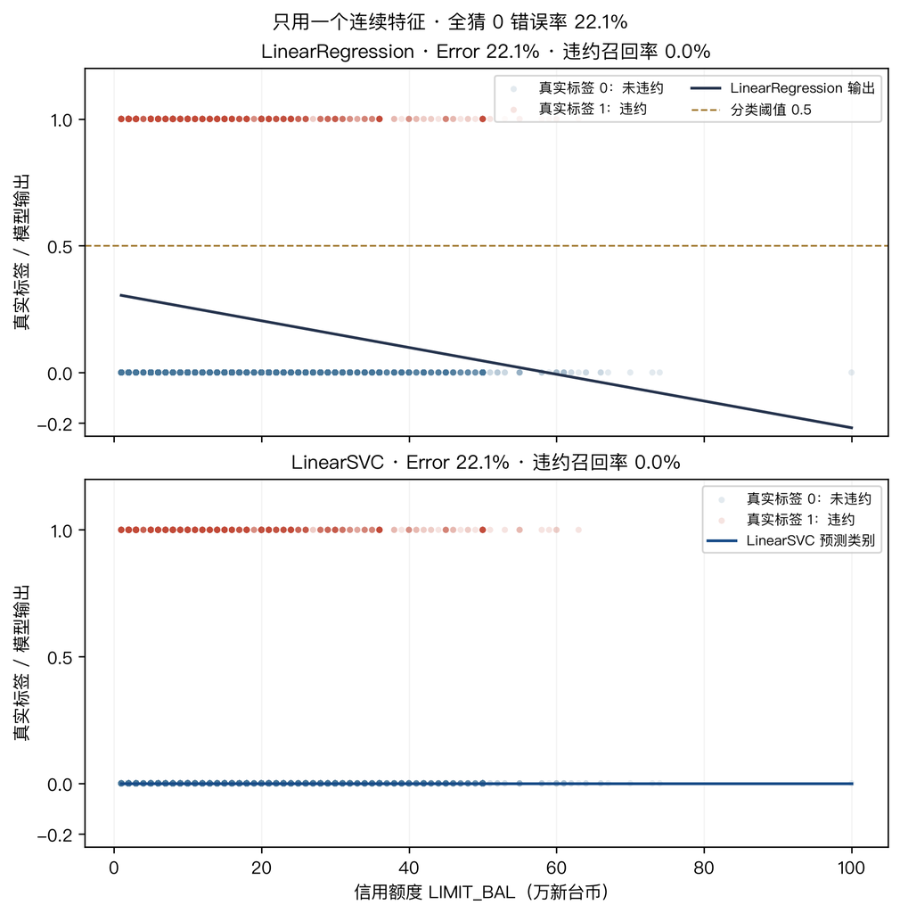

```python
plt.rcParams["font.sans-serif"] = ["PingFang SC", "Hiragino Sans GB", "Microsoft YaHei", "Arial Unicode MS", "DejaVu Sans"]
plt.rcParams["axes.unicode_minus"] = False
x_curve = np.linspace(X_valid[demo_feature].min(), X_valid[demo_feature].max(), 500)
x_frame = pd.DataFrame({demo_feature: x_curve})
regression_curve = linear_regression.predict(x_frame)
svc_curve = linear_svc.predict(x_frame)
fig, axes = plt.subplots(2, 1, figsize=(7.1, 7.2), sharex=True, sharey=True, layout="constrained")
for ax in axes:
    for label, color, name in [(0, "#46769A", "真实标签 0：未违约"), (1, "#C34B39", "真实标签 1：违约")]:
        mask = y_true == label
        ax.scatter(X_valid.loc[mask, demo_feature]/10000, y_true[mask], s=13, alpha=.15,
                   color=color, edgecolors="none", label=name)
    ax.set_ylim(-.25, 1.2)
    ax.set_yticks([-.2, 0, .5, 1])
    ax.set_ylabel("真实标签 / 模型输出")
    ax.grid(axis="x", alpha=.13)
axes[0].plot(x_curve/10000, regression_curve, color="#25334D", lw=1.6, label="LinearRegression 输出")
axes[0].axhline(.5, color="#A27A32", ls="--", lw=1, label="分类阈值 0.5")
axes[0].set_title(f"LinearRegression · Error {regression_error:.1%} · 违约召回率 {regression_recall:.1%}", fontsize=11)
axes[0].legend(loc="upper right", fontsize=8, ncol=2)
axes[1].step(x_curve/10000, svc_curve, where="mid", color="#174B87", lw=1.6, label="LinearSVC 预测类别")
axes[1].set_title(f"LinearSVC · Error {svc_error:.1%} · 违约召回率 {svc_recall:.1%}", fontsize=11)
axes[1].set_xlabel("信用额度 LIMIT_BAL（万新台币）")
axes[1].legend(loc="upper right", fontsize=8)
fig.suptitle(f"只用一个连续特征 · 全猜 0 错误率 {baseline_error:.1%}", fontsize=11)
fig.savefig(asset_dir / "lab04-linear-vs-logistic.png", dpi=200, facecolor="white")
plt.show()
```

## A2｜sigmoid 与阶跃

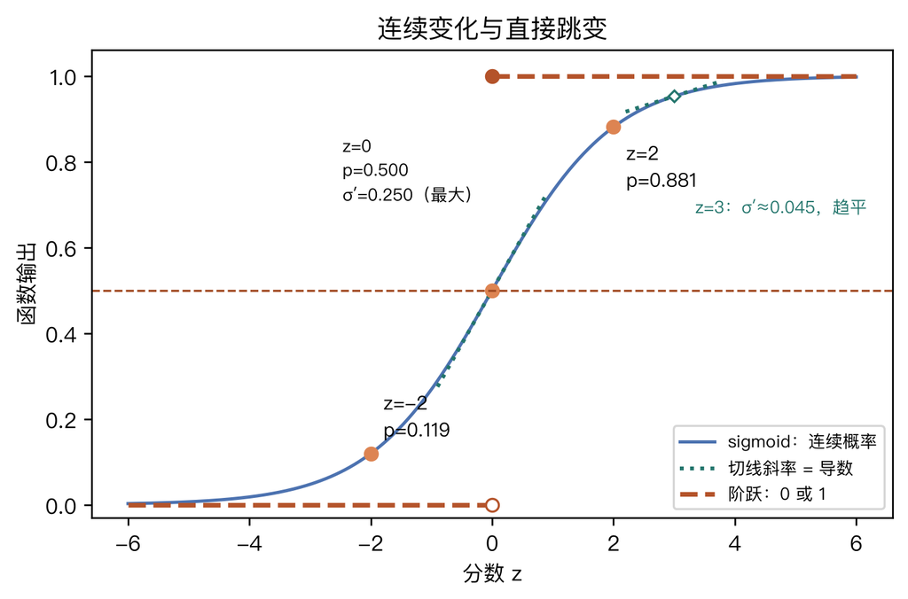

```python
# sigmoid 与硬阶跃：训练时的连续输出，预测时仍可阈值分类。
# 小结：z 越大概率越接近 1；z=0 恰好 0.5；三个标注点与手算一致
# 图内标签含中文：指定中文字体（macOS 为 PingFang SC，其余按序回退），并禁用 Unicode 负号
plt.rcParams["font.sans-serif"] = ["PingFang SC", "Hiragino Sans GB", "Microsoft YaHei", "Arial Unicode MS", "DejaVu Sans"]
plt.rcParams["axes.unicode_minus"] = False
zz = np.linspace(-6, 6, 300)
pp = 1 / (1 + np.exp(-zz))
fig, ax = plt.subplots(figsize=(6, 4))
ax.plot(zz, pp, color="#4C72B0", label="sigmoid：连续概率")
# 切线斜率就是 sigmoid 导数：中心较大，尾部较小。
ax.plot([-0.9, 0.9], [0.275, 0.725], color="#23756c", linestyle=":", linewidth=1.8, label="切线斜率 = 导数")
z_tail = 3.0
p_tail = 1 / (1 + np.exp(-z_tail))
slope_tail = p_tail * (1 - p_tail)
tail_x = np.array([2.2, 3.8])
ax.plot(tail_x, p_tail + slope_tail * (tail_x - z_tail), color="#23756c", linestyle=":", linewidth=1.8)
ax.plot(z_tail, p_tail, marker="D", markersize=4, markerfacecolor="white", markeredgecolor="#23756c")
ax.plot([-6, 0], [0, 0], color="#B4532A", linestyle="--", linewidth=2.2, label="阶跃：0 或 1")
ax.plot([0, 6], [1, 1], color="#B4532A", linestyle="--", linewidth=2.2)
ax.plot(0, 0, "o", color="#B4532A", markerfacecolor="white")
ax.plot(0, 1, "o", color="#B4532A")
for z0 in (-2, 0, 2):           # 三个标注点：与手算一致
    p0 = 1 / (1 + np.exp(-z0))
    ax.plot(z0, p0, "o", color="#DD8452")
    if z0 == 0:
        ax.annotate(f"z=0\np={p0:.3f}\nσ′={p0 * (1 - p0):.3f}（最大）", (z0, p0),
                    textcoords="offset points", xytext=(-70, 42), fontsize=8)
    else:
        ax.annotate(f"z={z0}\np={p0:.3f}", (z0, p0),
                    textcoords="offset points", xytext=(6, -28) if z0 == 2 else (6, 8), fontsize=9)
ax.text(3.35, 0.68, f"z=3：σ′≈{slope_tail:.3f}，趋平", fontsize=8, color="#23756c")
ax.axhline(0.5, color="#a14a22", linestyle="--", linewidth=1)
ax.legend(loc="lower right", fontsize=8)
ax.set(xlabel="分数 z", ylabel="函数输出", title="连续变化与直接跳变",
       ylim=(-0.03, 1.06))
plt.tight_layout()
from pathlib import Path
cwd = Path.cwd()
asset_dir.mkdir(parents=True, exist_ok=True)
fig.savefig(asset_dir / "lab03-sigmoid.png", dpi=180, bbox_inches="tight", facecolor="white")
plt.show()
```

## A3｜月牙数据决策边界

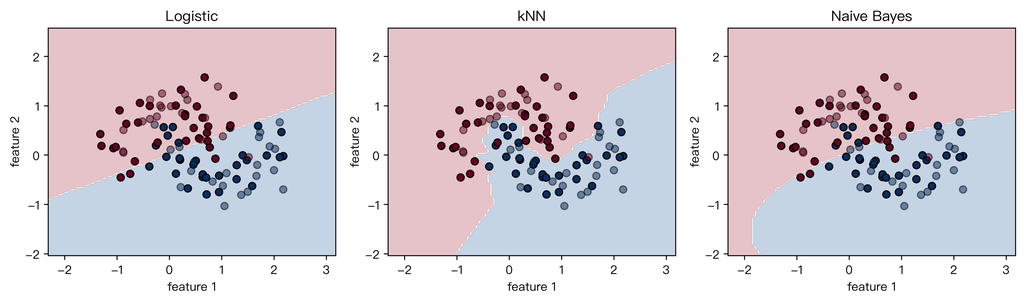

```python
from sklearn.inspection import DecisionBoundaryDisplay
fig, axes = plt.subplots(1, 3, figsize=(12, 3.6))
for ax, (name, model) in zip(axes, comparison_models.items()):
    DecisionBoundaryDisplay.from_estimator(
        model, X_small, ax=ax, response_method="predict", alpha=0.25, cmap="RdBu")
    ax.scatter(a[:, 0], a[:, 1], c=c, cmap="RdBu", edgecolors="k")
    ax.scatter(b[:, 0], b[:, 1], c=d, cmap="RdBu", edgecolors="k", alpha=0.5)
    ax.set_title(name)
    ax.set_xlabel("feature 1")
    ax.set_ylabel("feature 2")
plt.tight_layout()
fig.savefig(asset_dir / "lab04-moons-boundaries.png", dpi=240, bbox_inches="tight")
plt.show()
```

## A3b｜改变 k 后的边界

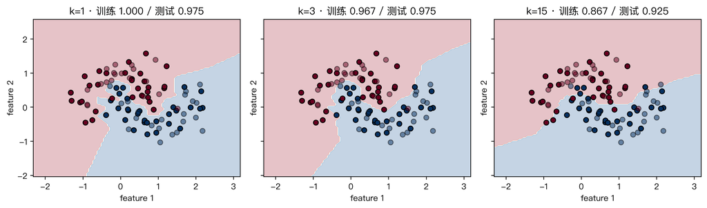

```python
fig, axes = plt.subplots(1, 3, figsize=(12, 3.6), sharex=True, sharey=True)
for ax, (neighbors, model) in zip(axes, knn_moons_models.items()):
    DecisionBoundaryDisplay.from_estimator(model, X_small, ax=ax,
                                           response_method="predict", alpha=0.25, cmap="RdBu")
    ax.scatter(a[:, 0], a[:, 1], c=c, cmap="RdBu", edgecolors="k", label="训练")
    ax.scatter(b[:, 0], b[:, 1], c=d, cmap="RdBu", edgecolors="k", alpha=0.5, label="测试")
    scores = knn_k_table.loc[knn_k_table["k"] == neighbors].iloc[0]
    ax.set(title=f"k={neighbors} · 训练 {scores['训练准确率']:.3f} / 测试 {scores['测试准确率']:.3f}",
           xlabel="feature 1", ylabel="feature 2")
fig.tight_layout()
fig.savefig(asset_dir / "lab04-knn-k-boundaries.png", dpi=240, bbox_inches="tight")
plt.show()
```

## A4｜验证集混淆矩阵

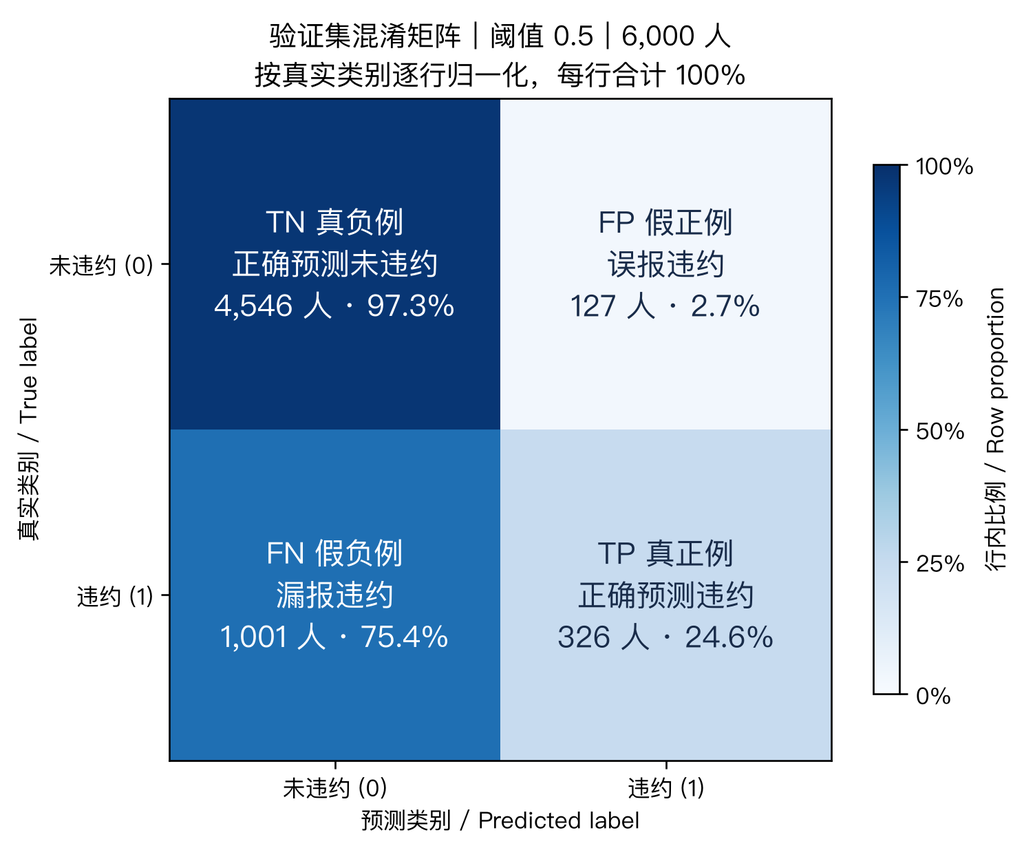

```python
# 绘图辅助代码：手动排列四个计数，不调用 confusion_matrix。
counts = valid_counts.copy()
row_totals = counts.sum(axis=1, keepdims=True)
# 检查每个真实类别都有样本，避免除以0。
assert (row_totals > 0).all(), "某个真实类别没有样本，无法计算该行比例"
row_rates = counts / row_totals  # 每格人数除以其所在行的总人数
names = [["TN 真负例\n正确预测未违约", "FP 假正例\n误报违约"],
         ["FN 假负例\n漏报违约", "TP 真正例\n正确预测违约"]]
fig, ax = plt.subplots(figsize=(6.4, 5.2))
image = ax.imshow(row_rates, cmap="Blues", vmin=0, vmax=1)
for row in range(2):
    for col in range(2):
        color = "white" if row_rates[row, col] > 0.6 else "#182b49"
        ax.text(col, row, f"{names[row][col]}\n{counts[row, col]:,} 人 · {row_rates[row, col]:.1%}",
                ha="center", va="center", fontsize=13, color=color)
ax.set_xticks([0, 1], ["未违约 (0)", "违约 (1)"])
ax.set_yticks([0, 1], ["未违约 (0)", "违约 (1)"])
ax.set(xlabel="预测类别 / Predicted label", ylabel="真实类别 / True label",
       title=f"验证集混淆矩阵｜阈值 {decision_threshold:g}｜{counts.sum():,} 人\n按真实类别逐行归一化，每行合计 100%")
colorbar = fig.colorbar(image, ax=ax, label="行内比例 / Row proportion", shrink=0.8)
colorbar.set_ticks([0, 0.25, 0.5, 0.75, 1], labels=["0%", "25%", "50%", "75%", "100%"])
fig.tight_layout()
fig.savefig(asset_dir / "manual-confusion-matrix.png", dpi=180, bbox_inches="tight")
plt.show()
```

## A5｜验证集阈值曲线

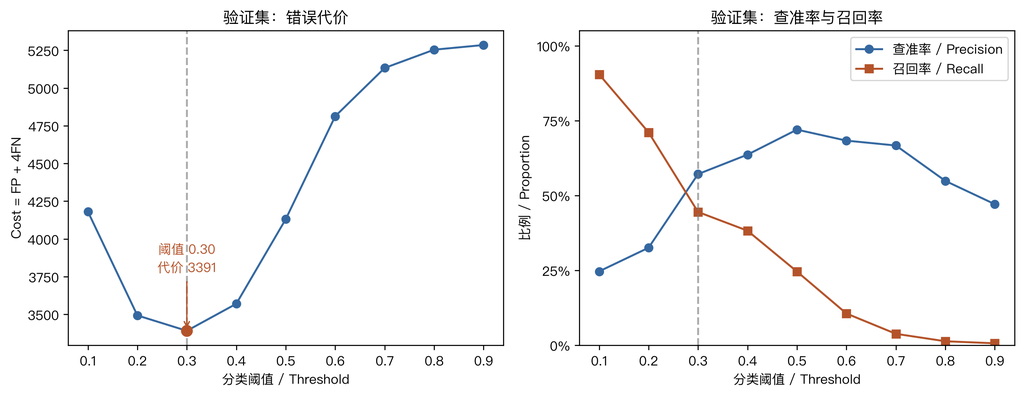

```python
# 绘图辅助：左图用于选阈值，右图解释查准率和召回率的变化。
fig, (ax_cost, ax_rates) = plt.subplots(1, 2, figsize=(11, 4.3), sharex=True)
ax_cost.plot(threshold_table["threshold"], threshold_table["cost=FP+4FN"],
             marker="o", color="#3568a0")
ax_cost.scatter(chosen, chosen_cost, color="#b4532a", s=65, zorder=3)
ax_cost.annotate(f"阈值 {chosen:.2f}\n代价 {chosen_cost:.0f}", (chosen, chosen_cost),
                 xytext=(0, 45), textcoords="offset points", ha="center", color="#b4532a",
                 arrowprops={"arrowstyle": "->", "color": "#b4532a"})
ax_cost.set(title="验证集：错误代价", ylabel="Cost = FP + 4FN")
ax_rates.plot(threshold_table["threshold"], threshold_table["precision"],
              marker="o", color="#3568a0", label="查准率 / Precision")
ax_rates.plot(threshold_table["threshold"], threshold_table["recall"],
              marker="s", color="#b4532a", label="召回率 / Recall")
ax_rates.set(title="验证集：查准率与召回率", ylabel="比例 / Proportion", ylim=(0, 1.05))
ax_rates.set_yticks([0, 0.25, 0.5, 0.75, 1], labels=["0%", "25%", "50%", "75%", "100%"])
ax_rates.legend()
for ax in (ax_cost, ax_rates):
    ax.axvline(chosen, color="#777777", linestyle="--", alpha=0.6)
    ax.set_xlabel("分类阈值 / Threshold")
fig.tight_layout()
fig.savefig(asset_dir / "lab03-threshold-cost.png", dpi=240, bbox_inches="tight")
plt.show()
```

## A6｜测试集阈值对照

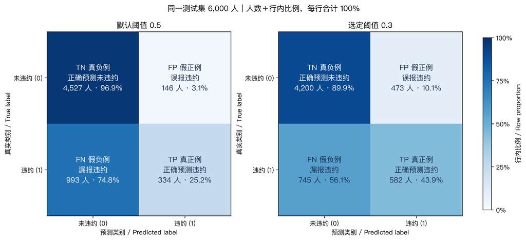

```python
# 绘图辅助：直接计数，使用人数＋行归一化比例的同一种样式。
actual_test = y_final.to_numpy()
cell_names = [["TN 真负例\n正确预测未违约", "FP 假正例\n误报违约"],
              ["FN 假负例\n漏报违约", "TP 真正例\n正确预测违约"]]
fig, axes = plt.subplots(1, 2, figsize=(11.4, 5.2), layout="constrained")
for ax, (label, threshold) in zip(axes, [("默认阈值", baseline_threshold), ("选定阈值", chosen)]):
    pred = test_predictions[label]
    counts = np.array([[((actual_test == 0) & (pred == 0)).sum(), ((actual_test == 0) & (pred == 1)).sum()],
                       [((actual_test == 1) & (pred == 0)).sum(), ((actual_test == 1) & (pred == 1)).sum()]])
    row_totals = counts.sum(axis=1, keepdims=True)
    # 检查每个真实类别都有样本，避免除以0。
    assert (row_totals > 0).all(), "真实类别无样本时，该行比例没有定义"
    rates = counts / row_totals
    image = ax.imshow(rates, cmap="Blues", vmin=0, vmax=1)
    for row in range(2):
        for col in range(2):
            color = "white" if rates[row, col] > 0.6 else "#182b49"
            ax.text(col, row, f"{cell_names[row][col]}\n{counts[row, col]:,} 人 · {rates[row, col]:.1%}",
                    ha="center", va="center", fontsize=11.5, color=color)
    ax.set_xticks([0, 1], ["未违约 (0)", "违约 (1)"])
    ax.set_yticks([0, 1], ["未违约 (0)", "违约 (1)"])
    ax.set(title=f"{label} {threshold:g}", xlabel="预测类别 / Predicted label", ylabel="真实类别 / True label")
fig.suptitle(f"同一测试集 {len(actual_test):,} 人｜人数＋行内比例，每行合计 100%")
colorbar = fig.colorbar(image, ax=axes, label="行内比例 / Row proportion", shrink=0.8)
colorbar.set_ticks([0, 0.25, 0.5, 0.75, 1], labels=["0%", "25%", "50%", "75%", "100%"])
fig.savefig(asset_dir / "test-threshold-comparison.png", dpi=240, bbox_inches="tight")
plt.show()
```

## B｜kNN 搜索方法：计时与选择因素

### B.1｜固定查询集，测量样本数变化后的查询耗时

使用随机种子 42 的嵌套训练子集；所有规模使用同一个训练集拟合的缩放器和同一批 200 个验证查询，目的是隔离搜索规模，不评估子集模型的准确率。只计 `kneighbors`，不计标准化和 `fit`。限制数值计算线程为 1，预热一次、重复五次取中位数。

以下短函数只负责计时，模型的拟合与搜索接口仍在课堂代码中可见。

```python
from time import perf_counter
from threadpoolctl import threadpool_limits
import platform, sklearn

def median_query_ms(model, queries, repeats=5):
    model.kneighbors(queries)  # 预热，不计入结果
    elapsed = []
    for _ in range(repeats):
        started = perf_counter()
        model.kneighbors(queries)
        elapsed.append((perf_counter() - started) * 1000)
    return float(np.median(elapsed))

print("运行环境:", platform.platform(), "sklearn", sklearn.__version__)
knn_order = np.random.default_rng(42).permutation(len(knn_train))
```

```
运行环境: macOS-27.0.1-arm64-arm-64bit-Mach-O sklearn 1.9.0
```

先做暴力搜索的规模对照。数组准备放在计时外；训练子集大小变化时，距离次数会变化，耗时还受到实现、缓存与固定开销影响。

```python
knn_scale_rows = []
with threadpool_limits(limits=1):
    for n_train in knn_sizes:
        positions = knn_order[:n_train]
        candidate = KNeighborsClassifier(n_neighbors=3, algorithm="brute", n_jobs=1)
        candidate.fit(knn_train[positions], y_fit.iloc[positions])
        query_ms = median_query_ms(candidate, knn_queries)
        knn_scale_rows.append({"训练样本数": n_train,
                              "200次查询距离次数": n_train * len(knn_queries),
                              "查询中位耗时 ms": query_ms})
knn_scale_table = pd.DataFrame(knn_scale_rows)
display(knn_scale_table.round(3))
```

|  | 训练样本数 | 200次查询距离次数 | 查询中位耗时 ms |
| --- | --- | --- | --- |
| 0 | 1000 | 200000 | 0.421 |
| 1 | 3000 | 600000 | 1.088 |
| 2 | 6000 | 1200000 | 2.094 |
| 3 | 18000 | 3600000 | 5.994 |

### B.2｜同一批数据上，树索引一定更快吗？

保持 n=18,000、d=8、k=3 和查询集不变，只改变搜索实现。准备耗时为单次 `fit` 的计时，包括检查和索引构建，不含前面的标准化；查询耗时则重复五次取中位数。两者都不是部署的全流程耗时。

```python
knn_search_rows = []
with threadpool_limits(limits=1):
    for search in ["brute", "kd_tree", "ball_tree"]:
        candidate = KNeighborsClassifier(n_neighbors=3, algorithm=search, n_jobs=1)
        started = perf_counter()
        candidate.fit(knn_train, y_fit)
        fit_ms = (perf_counter() - started) * 1000
        query_ms = median_query_ms(candidate, knn_queries)
        knn_search_rows.append({"搜索方法": search, "准备耗时 ms": fit_ms,
                                "200次查询中位耗时 ms": query_ms})
knn_search_table = pd.DataFrame(knn_search_rows)
display(knn_search_table.round(3))
```

|  | 搜索方法 | 准备耗时 ms | 200次查询中位耗时 ms |
| --- | --- | --- | --- |
| 0 | brute | 0.648 | 6.004 |
| 1 | kd_tree | 3.537 | 1.163 |
| 2 | ball_tree | 3.480 | 6.189 |

读表时分开看准备和查询两列。树索引花时间组织数据，再尝试减少距离计算；是否划算取决于数据结构和查询量。这只是当前机器、八维数据、k=3 的测量，不能据此说某种方法在所有高维数据中最好，也不能用四个规模的耗时“证明”Big-O。

### 思考与改动实验

假设 Logistic 回归与 kNN 的验证效果接近，每天要预测十万名新客户，你会因为 kNN 训练快而选它吗？减小 k 能解决暴力查询成本吗？

先写理由，再将上面的搜索对照改为 k=1 或 k=15，重跑最后一小节；不要据计时结果选分类超参数。

**参考解释**

不能只比较训练速度，还要看单次查询延迟、吞吐量、内存以及更新频率。基本 kNN 的暴力查询仍需遍历 n 个训练样本，减小 k 并不消除 O(nd) 的距离计算；树查询会受 k 和数据结构影响，需实测。Logistic 回归先拟合参数，二分类预测通常只需 O(d) 的线性得分和 sigmoid（不计共同预处理）。验证效果接近是题设，不是本节已证明的实验结论。

来源：[UCI 数据集](https://doi.org/10.24432/C55S3H)（本地数据卡见 `data/README.md`）；[sklearn：KNeighborsClassifier](https://scikit-learn.org/stable/modules/generated/sklearn.neighbors.KNeighborsClassifier.html)；[近邻搜索算法选择](https://scikit-learn.org/stable/modules/neighbors.html#choice-of-nearest-neighbors-algorithm)。接口核查 2026-10-01。

### B.3｜近邻搜索如何选型？

上面的 UCI 实验只对比了样本数和三种搜索实现，没有检验所有维数或分布。下面解释影响搜索成本的因素，不把一次计时当成普遍排名。

| 因素 | 对搜索成本的影响 |
| --- | --- |
| 样本数 n 与特征数 d | 暴力搜索逐个计算距离；样本很少时，建树开销可能不值得。维数增加通常不利于 KD-Tree 剪枝。 |
| 数据结构 | 内在维数（intrinsic dimensionality）是描述数据实际变化所需的维数：例如三维空间里的点可能主要沿一条曲线变化。可排除的区域越多，树查询越有机会省计算。 |
| 近邻数 k | k 大时要搜索更大区域、保留更多候选，树的优势可能下降。暴力搜索仍要算 n 个距离，但近邻选择和投票成本会随 k 变化。 |
| 查询数 m | 建树是一次性成本，多次查询可以分摊；查询很少时应比较“准备＋查询”，不能只看查询列。 |

这里的“结构稀疏”指点没有填满特征空间，不是说矩阵里有很多零。KD-Tree 沿坐标轴切分，Ball-Tree 用球形区域组织样本；哪种更容易排除无关区域，还取决于数据几何形状。

### B.4｜复杂度要说明条件

n 为训练样本数、d 为特征数。密集欧氏距离的暴力查询需 O(nd) 距离计算；若采用线性选择找近邻，再加 O(k) 投票，整体为 O(nd)。全排序则还需 O(n log n)，并非必需。

在小 k、数据结构适合剪枝等有利条件下，树查询可接近 O(d log n)；这不是最坏情况保证。剪枝失效时仍可能检查全部样本，接近 O(nd)，还多了遍历树的开销。Ball-Tree 并非一定在高维失效。

一次建索引后的总成本可近似理解为：**准备成本＋m × 平均单次查询成本**。批量查询会受缓存和实现优化影响，应直接测量目标批量。维数约 20、样本数约 30 是文档中的经验范围，不是普适分界线。

### B.5｜leaf_size 与 auto 不是“自动保证最快”

叶大小（leaf_size）决定树划分的粒度，叶节点内部使用暴力搜索。叶子太小，遍历开销可能增加；太大，叶内距离计算更多。较大的叶子一般减少节点数、建树成本和索引内存，但查询速度未必更快。KNeighborsClassifier 默认 leaf_size=30；暴力搜索不使用这个参数。

按 sklearn 1.9 用户指南，algorithm='auto' 遇到以下情况之一时倾向选择 brute：

- 输入是稀疏矩阵，或 metric='precomputed'；
- 特征数 d>15，或 k 至少约为训练样本的一半；
- 实际距离度量不受两种树支持。

否则按度量支持情况优先选择 KD-Tree，再考虑 Ball-Tree。文档规则中的“半数”，本地 1.9.0 实现使用 n_samples // 2 判断。15 是实现启发式阈值，不是维度灾难的数学界限。

auto 根据数据和参数选方法，不会把三种算法逐一计时。该启发式假定查询量较多、leaf_size 接近默认值；若只查询一次或数据结构特殊，应自行比较。规则可能随版本变化。

来源：[sklearn 1.9：算法选择](https://scikit-learn.org/1.9/modules/neighbors.html#choice-of-nearest-neighbors-algorithm)、[叶大小的影响](https://scikit-learn.org/1.9/modules/neighbors.html#effect-of-leaf-size)。核查 2026-10-01。

### B.6｜思考：搜索更快，分类就更好吗？

保持训练数据、标准化、距离、k 和投票权重不变，只把 brute 换成 kd_tree，准确率应该提高吗？如果查询量从一次变成十万次，搜索方法的选择可能改变吗？

**参考解释**

三者是精确近邻搜索，改变的是找邻居的方法，不是分类规则。若第 k 个邻居处没有距离并列且数值计算一致，应得到相同邻居和预测；存在并列或浮点差异时，结果可能受顺序影响。查询量增加可能让建树更值得，却不意味着分类效果提高。

用已有实验继续验证时，先固定分类参数，再比较准备成本与实际查询批量的耗时。改变 k 属于改变模型，须另用验证集比较分类效果；改变搜索实现主要是在比较计算成本。

### B.7｜扩展阅读：维数增加，“近”和“远”还差多少？

这里演示**维度灾难（curse of dimensionality）**中的距离集中，而非多项式展开后的特征数量爆炸。固定2,000个候选邻居、20个独立查询点，各坐标独立来自标准正态分布；只改变使用的维数，不训练分类器，也不使用UCI数据。

对每个查询计算到所有候选点的欧氏距离，记录最近距离与最远距离。用相对差距 $(d_{\max}-d_{\min})/d_{\max}$ 比较：越接近0，最近与最远在相对尺度上越难区分。用20次查询的平均值，避免只看一个点。

```python
from scipy.spatial.distance import cdist
dimension_rng = np.random.default_rng(42)
dimension_candidates = dimension_rng.normal(size=(2000, 500))
dimension_queries = dimension_rng.normal(size=(20, 500))
dimension_rows = []
for dimension in [2, 10, 50, 100, 500]:
    distances = cdist(dimension_queries[:, :dimension], dimension_candidates[:, :dimension])
    nearest, farthest = distances.min(axis=1), distances.max(axis=1)
    dimension_rows.append({"维数 d": dimension, "平均最近距离": nearest.mean(),
                           "平均最远距离": farthest.mean(), "平均相对差距": (1 - nearest / farthest).mean()})
dimension_table = pd.DataFrame(dimension_rows).set_index("维数 d")
display(dimension_table.style.format({"平均最近距离": "{:.2f}", "平均最远距离": "{:.2f}", "平均相对差距": "{:.1%}"}))
```

| 维数 d | 平均最近距离 | 平均最远距离 | 平均相对差距 |
| --- | --- | --- | --- |
| 2 | 0.05 | 5.00 | 99.1% |
| 10 | 1.73 | 7.60 | 77.2% |
| 50 | 7.14 | 13.13 | 45.6% |
| 100 | 11.16 | 17.00 | 34.4% |
| 500 | 28.61 | 34.69 | 17.5% |

### 用图看相对差距

条越短，最近距离与最远距离的相对差距越小；并不是“距离都变小了”。图中的每条都是上表20次独立查询的平均值。以下为辅助绘图代码，不重复生成数据。

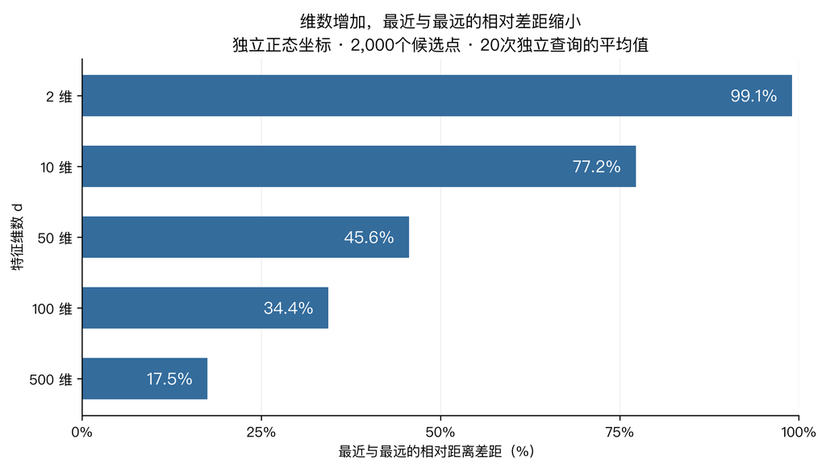

```python
dimension_gap = 100 * dimension_table["平均相对差距"]
fig, ax = plt.subplots(figsize=(8.2, 4.6), layout="constrained")
bars = ax.barh([f"{d} 维" for d in dimension_gap.index], dimension_gap, color="#346C9C", height=0.58)
for bar, value in zip(bars, dimension_gap):
    ax.text(value - 2, bar.get_y() + bar.get_height()/2, f"{value:.1f}%", ha="right", va="center", color="white", fontsize=12)
ax.invert_yaxis()
ax.set(xlim=(0, 100), xlabel="最近与最远的相对距离差距（%）", ylabel="特征维数 d",
       title="维数增加，最近与最远的相对差距缩小\n独立正态坐标 · 2,000个候选点 · 20次独立查询的平均值")
ax.set_xticks([0, 25, 50, 75, 100], ["0%", "25%", "50%", "75%", "100%"])
ax.grid(axis="x", alpha=0.18); ax.set_axisbelow(True)
ax.spines[["top", "right"]].set_visible(False)
fig.savefig(asset_dir / "lab04-knn-dimension-concentration.png", dpi=220, facecolor="white")
plt.show()
```

**读表**：看最后一列，而不是只比较绝对距离。在这个独立随机坐标的例子中，维数增加时相对差距缩小：最近邻仍然存在，但它比远处样本近多少，越来越不明显。标准化不能消除这种现象，因为各坐标本来就有相同尺度。

这不是“高维时kNN一定失败”的证明：本例没有标签，也没有测分类准确率；真实数据的有效特征、内在维数和结构都会影响结果。

**想一想**：给原本有用的特征追加很多独立噪声列，再标准化，能保证邻居仍有意义吗？

**参考解释**

不能。标准化调整各列尺度，但不会识别哪些列与标签有关；大量噪声列仍会累积进欧氏距离，可能掩盖有用特征。可以用训练/验证数据检验特征选择或降维的效果，不能仅凭此无标签实验断言分类一定变差。

延伸阅读：[scikit-learn：近邻算法选择](https://scikit-learn.org/stable/modules/neighbors.html#choice-of-nearest-neighbors-algorithm)（特别是维数与内在维数的讨论）。

## 可选附录｜分类为什么常用交叉熵？

固定真实标签 `y=1`，令 `p = sigmoid(z)`。上图比较最终错分目标（0–1 损失）、概率平方差（MSE）和真实标签的负对数概率（交叉熵）；下图比较它们对线性分数 `z` 的梯度大小。

曲线由公式直接计算，不使用信用卡样本，也不是模型训练结果。`y=0` 时曲线关于 `z=0` 左右镜像。

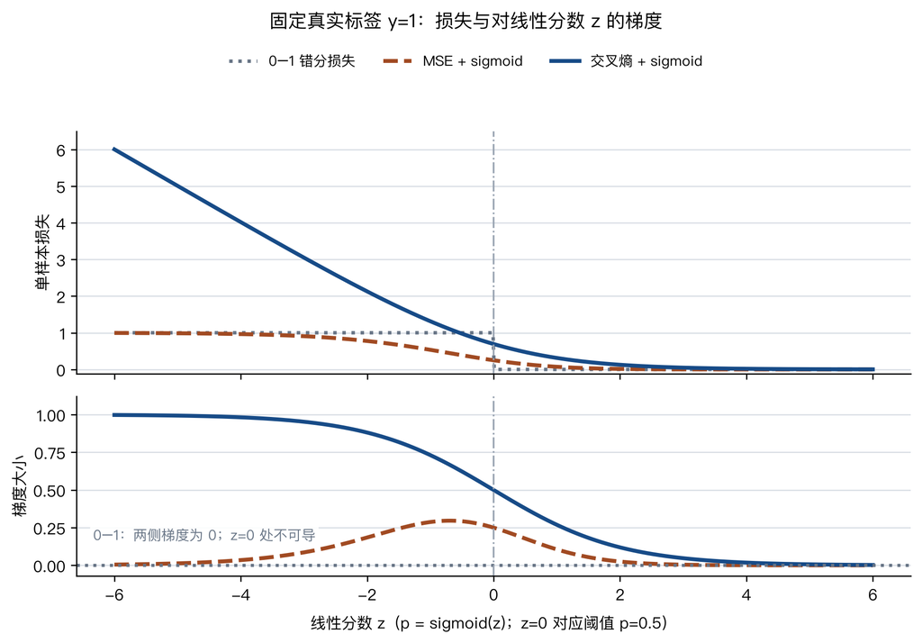

```
自信错分端 z=-6、p=0.0025：|dℓ_MSE/dz|=0.0049，|dℓ_CE/dz|=0.9975
```

```python
z_loss = np.linspace(-6, 6, 600)
p_loss = 1 / (1 + np.exp(-z_loss))

# 固定 y=1：z<0 时预测为 0，产生一次错分。
loss_01 = (z_loss < 0).astype(float)
loss_mse = (p_loss - 1) ** 2
loss_ce = np.logaddexp(0, -z_loss)  # -log(sigmoid(z))，稳定计算

grad_mse = np.abs(2 * (p_loss - 1) * p_loss * (1 - p_loss))
grad_ce = np.abs(p_loss - 1)

fig, (ax_loss, ax_grad) = plt.subplots(
    2, 1, figsize=(8.2, 5.9), sharex=True,
    gridspec_kw={"height_ratios": [1.15, 0.85]},
)
colors = {"zero_one": "#687586", "mse": "#A14A22", "ce": "#174B87"}
ax_loss.plot(z_loss, loss_01, color=colors["zero_one"], linestyle=":", linewidth=2.2,
             label="0–1 错分损失")
ax_loss.plot(z_loss, loss_mse, color=colors["mse"], linestyle="--", linewidth=2.5,
             label="MSE + sigmoid")
ax_loss.plot(z_loss, loss_ce, color=colors["ce"], linewidth=2.5,
             label="交叉熵 + sigmoid")
ax_loss.set_ylabel("单样本损失")
ax_loss.set_ylim(-0.12, 6.5)
ax_grad.plot(z_loss, grad_mse, color=colors["mse"], linestyle="--", linewidth=2.5,
             label="MSE：|dℓ/dz|")
ax_grad.plot(z_loss, grad_ce, color=colors["ce"], linewidth=2.5,
             label="交叉熵：|dℓ/dz|")
ax_grad.axhline(0, color=colors["zero_one"], linestyle=":", linewidth=2,
                label="0–1：两侧梯度为 0")
for ax in (ax_loss, ax_grad):
    ax.axvline(0, color="#9AA4B2", linestyle="-.", linewidth=1.1)
    ax.grid(axis="y", color="#D9DEE5", linewidth=0.8)
    ax.spines[["top", "right"]].set_visible(False)
ax_grad.text(0.02, 0.2, "0–1：两侧梯度为 0；z=0 处不可导",
             transform=ax_grad.transAxes, color=colors["zero_one"], fontsize=9,
             bbox={"facecolor": "white", "edgecolor": "none", "alpha": 0.9, "pad": 2})
ax_grad.set_ylabel("梯度大小")
ax_grad.set_xlabel("线性分数 z（p = sigmoid(z)；z=0 对应阈值 p=0.5）", labelpad=8)
ax_grad.set_ylim(-0.07, 1.12)

fig.suptitle("固定真实标签 y=1：损失与对线性分数 z 的梯度", y=0.98)
handles, labels = ax_loss.get_legend_handles_labels()
fig.legend(handles, labels, frameon=False, ncol=3, loc="upper center",
           bbox_to_anchor=(0.5, 0.935), fontsize=9)
fig.tight_layout(rect=[0, 0.02, 1, 0.88], h_pad=1.1)

figure_path = asset_dir / "lab04-loss-choice.png"
fig.savefig(figure_path, dpi=180, bbox_inches="tight", facecolor="white")
plt.show()

wrong_end = np.argmin(np.abs(z_loss + 6))
print(f"自信错分端 z=-6、p={p_loss[wrong_end]:.4f}："
      f"|dℓ_MSE/dz|={grad_mse[wrong_end]:.4f}，"
      f"|dℓ_CE/dz|={grad_ce[wrong_end]:.4f}")
```

## 可选附录｜三种分类损失的形状

主课件把分类损失拆成三页。图中同时对照真实标签 `y=1` 与 `y=0`：横轴是模型预测为正类的概率 `p`，真实类别概率分别为 `q=p` 与 `q=1−p`。0–1 损失在阈值处跳变；MSE 是平方差；交叉熵是 `−ln(q)`。这些公式图不使用信用卡样本，也不是模型训练结果。

```python
from pathlib import Path

q = np.linspace(0, 1, 501)
colors = {"zero_one": "#687586", "mse": "#A14A22", "ce": "#174B87"}
asset_dir.mkdir(parents=True, exist_ok=True)
```

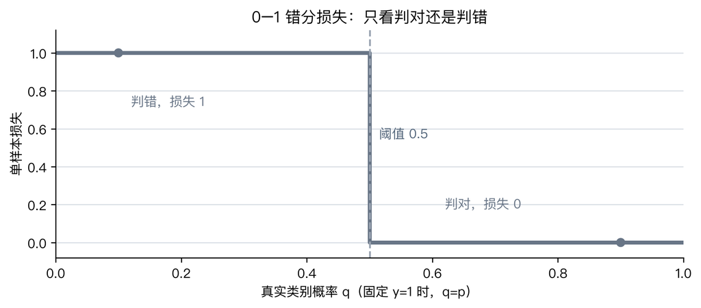

```python
# 1. 错分损失：固定 y=1，q=p；p<0.5 判错，p>=0.5 判对。
loss_01_q = (q < 0.5).astype(float)
fig, ax = plt.subplots(figsize=(7.6, 3.4))
ax.step(q, loss_01_q, where="post", color=colors["zero_one"], linewidth=3)
ax.axvline(0.5, color="#9AA4B2", linestyle="--", linewidth=1.4)
ax.scatter([0.1, 0.9], [1, 0], color=[colors["zero_one"]]*2, zorder=3)
ax.text(0.12, 0.72, "判错，损失 1", color=colors["zero_one"])
ax.text(0.62, 0.18, "判对，损失 0", color=colors["zero_one"])
ax.text(0.515, 0.55, "阈值 0.5", color="#52657A", fontsize=10)
ax.set(xlim=(0, 1), ylim=(-0.08, 1.12), xlabel="真实类别概率 q（固定 y=1 时，q=p）", ylabel="单样本损失", title="0–1 错分损失：只看判对还是判错")
ax.grid(axis="y", color="#D9DEE5", linewidth=0.8)
ax.spines[["top", "right"]].set_visible(False)
fig.tight_layout()
fig.savefig(asset_dir / "lab04-loss-01.png", dpi=180, bbox_inches="tight", facecolor="white")
plt.show()
```

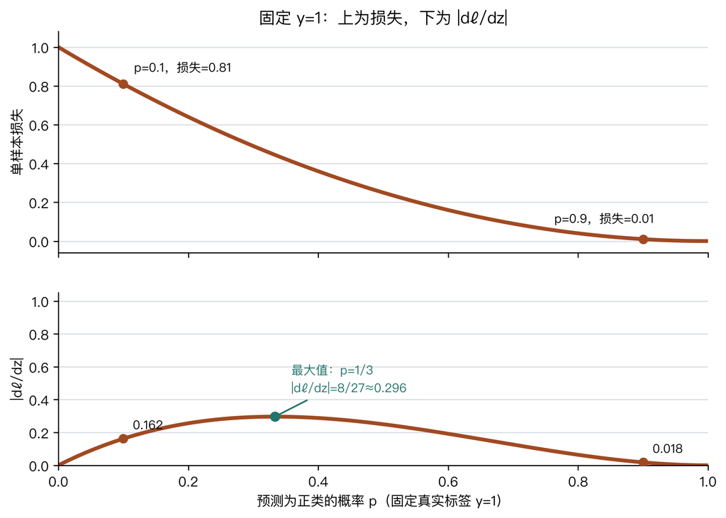

```python
# 2. MSE：同一张图对照损失与传回线性分数 z 的梯度大小（固定 y=1，q=p）。
loss_mse_q = (q - 1) ** 2
grad_mse_q = 2 * q * (1 - q) ** 2
p_grad_max = 1 / 3
grad_max = 8 / 27
fig, (ax_loss, ax_grad) = plt.subplots(2, 1, figsize=(7.6, 5.4), sharex=True, gridspec_kw={"height_ratios": [1, 0.78]})
ax_loss.plot(q, loss_mse_q, color=colors["mse"], linewidth=2.8)
ax_grad.plot(q, grad_mse_q, color=colors["mse"], linewidth=2.8)
ax_grad.scatter([p_grad_max], [grad_max], color="#23756C", s=42, zorder=4)
ax_grad.annotate("最大值：p=1/3\n|dℓ/dz|=8/27≈0.296", (p_grad_max, grad_max), xytext=(12, 18), textcoords="offset points", color="#23756C", fontsize=9, arrowprops={"arrowstyle": "-", "color": "#23756C", "lw": 1.2})
for qi in (0.1, 0.9):
    li = (qi - 1) ** 2
    gi = 2 * qi * (1 - qi) ** 2
    ax_loss.scatter([qi], [li], color=colors["mse"], zorder=3)
    ax_loss.annotate(f"p={qi:.1f}，损失={li:.2f}", (qi, li), xytext=(8, 9 if qi < 0.5 else 12), textcoords="offset points", ha="left" if qi < 0.5 else "right", fontsize=9)
    ax_grad.scatter([qi], [gi], color=colors["mse"], zorder=3)
    ax_grad.annotate(f"{gi:.3f}", (qi, gi), xytext=(7, 7), textcoords="offset points", fontsize=9)
ax_loss.set(ylim=(-0.06, 1.08), ylabel="单样本损失", title="固定 y=1：上为损失，下为 |dℓ/dz|")
ax_grad.set(xlim=(0, 1), ylim=(0, 1.05), xlabel="预测为正类的概率 p（固定真实标签 y=1）", ylabel="|dℓ/dz|")
for ax in (ax_loss, ax_grad):
    ax.grid(axis="y", color="#D9DEE5", linewidth=0.8)
    ax.spines[["top", "right"]].set_visible(False)
fig.tight_layout(h_pad=2.6)
fig.savefig(asset_dir / "lab04-loss-mse.png", dpi=180, bbox_inches="tight", facecolor="white")
plt.show()
```

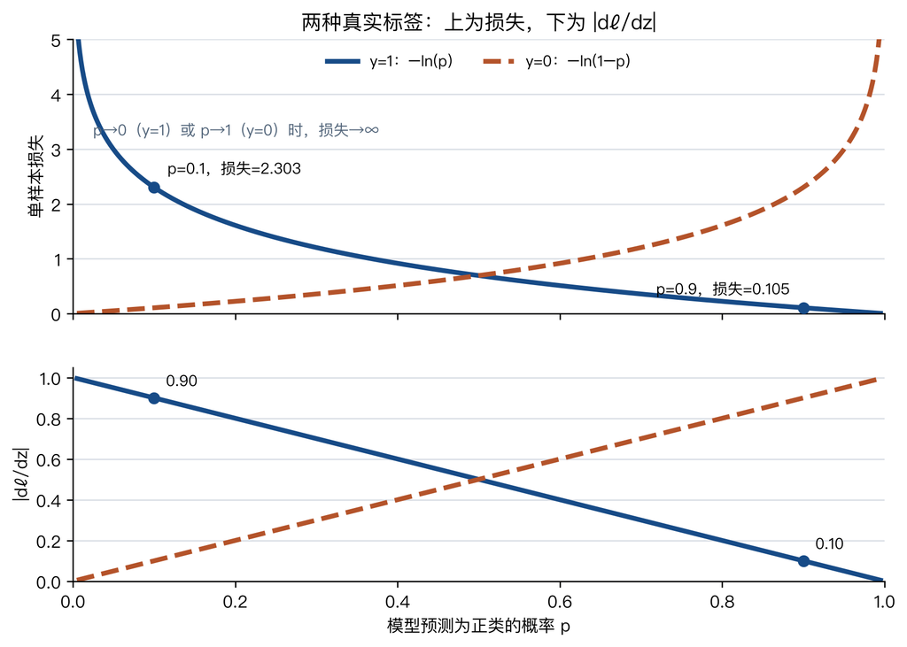

```python
# 3. 交叉熵：同时展示 y=1（q=p）与 y=0（q=1-p）。
q_ce = np.linspace(0.005, 0.995, 600)
loss_ce_q = -np.log(q_ce)
grad_ce_q = 1 - q_ce
loss_ce_y0 = -np.log1p(-q_ce)
grad_ce_y0 = q_ce
fig, (ax_loss, ax_grad) = plt.subplots(2, 1, figsize=(7.6, 5.4), sharex=True, gridspec_kw={"height_ratios": [1, 0.78]})
y0_color = "#B4532A"
ax_loss.plot(q_ce, loss_ce_q, color=colors["ce"], linewidth=2.8, label="y=1：−ln(p)")
ax_loss.plot(q_ce, loss_ce_y0, color=y0_color, linewidth=2.8, linestyle="--", label="y=0：−ln(1−p)")
ax_grad.plot(q_ce, grad_ce_q, color=colors["ce"], linewidth=2.8)
ax_grad.plot(q_ce, grad_ce_y0, color=y0_color, linewidth=2.8, linestyle="--")
for qi in (0.1, 0.9):
    li = -np.log(qi)
    gi = 1 - qi
    ax_loss.scatter([qi], [li], color=colors["ce"], zorder=3)
    ax_loss.annotate(f"p={qi:.1f}，损失={li:.3f}", (qi, li), xytext=(8, 8) if qi < 0.5 else (-8, 8), textcoords="offset points", ha="left" if qi < 0.5 else "right", fontsize=9)
    ax_grad.scatter([qi], [gi], color=colors["ce"], zorder=3)
    ax_grad.annotate(f"{gi:.2f}", (qi, gi), xytext=(7, 7), textcoords="offset points", fontsize=9)
ax_loss.text(0.025, 3.25, "p→0（y=1）或 p→1（y=0）时，损失→∞", color="#52657A", fontsize=9)
ax_loss.set(ylim=(0, 5), ylabel="单样本损失", title="两种真实标签：上为损失，下为 |dℓ/dz|")
ax_grad.set(xlim=(0, 1), ylim=(0, 1.05), xlabel="模型预测为正类的概率 p", ylabel="|dℓ/dz|")
for ax in (ax_loss, ax_grad):
    ax.grid(axis="y", color="#D9DEE5", linewidth=0.8)
    ax.spines[["top", "right"]].set_visible(False)
ax_loss.legend(frameon=False, loc="upper center", ncol=2, fontsize=9)
fig.tight_layout(h_pad=2.6)
fig.savefig(asset_dir / "lab04-loss-ce.png", dpi=180, bbox_inches="tight", facecolor="white")
plt.show()
```

```python
# 用有限差分核对两种可导损失对 z 的解析导数（y=1，p=0.1）。
y_check = 1.0
p_check = 0.1
z_check = np.log(p_check / (1 - p_check))
eps = 1e-6

def sigmoid(z):
    return 1 / (1 + np.exp(-z))

def mse_from_z(z):
    return (sigmoid(z) - y_check) ** 2

def ce_from_z(z):
    return -np.log(sigmoid(z))

mse_analytic = 2 * (p_check - y_check) * p_check * (1 - p_check)
ce_analytic = p_check - y_check
mse_numeric = (mse_from_z(z_check + eps) - mse_from_z(z_check - eps)) / (2 * eps)
ce_numeric = (ce_from_z(z_check + eps) - ce_from_z(z_check - eps)) / (2 * eps)
np.testing.assert_allclose([mse_numeric, ce_numeric], [mse_analytic, ce_analytic], rtol=1e-6)
print(f"y=1, p=0.1：MSE dℓ/dz={mse_analytic:.3f}，交叉熵 dℓ/dz={ce_analytic:.3f}；解析导数与有限差分一致。")
```

```
y=1, p=0.1：MSE dℓ/dz=-0.162，交叉熵 dℓ/dz=-0.900；解析导数与有限差分一致。
```

## 可选附录｜Logistic 回归为什么用 Logistic sigmoid？

广义上，sigmoid 指一类 S 形函数；本课二分类 Logistic 回归采用 Logistic sigmoid。tanh 也是 S 形函数。图中给出 Logistic sigmoid 的中心对称关系 $\sigma(-x)=1-\sigma(x)$，以及两曲线的中心和值域。

对概率 $p$，几率为 $\operatorname{odds}=p/(1-p)$，$\operatorname{logit}(p)=\ln[\operatorname{odds}]$，即几率的自然对数。例如 $p=0.5$ 时 odds=1、logit=0；$p=0.75$ 时 odds=3、logit$\approx1.10$。logit 将 $(0,1)$ 映到全体实数。 对 0/1 标签，常用 Bernoulli 概率模型；令 $\operatorname{logit}(p)$ 随特征线性变化，是它的标准连接方式（canonical link）。这样系数描述 log-odds 的线性变化，再用逆变换 $p=\sigma(z)=1/(1+e^{-z})$ 得到合法概率。Probit 等连接也能用；logit 是常用基准，不是唯一选项。tanh 原始输出含负值，不能直接作为概率；缩放平移为 $[1+\tanh(z/2)]/2$ 后，恰好就是同一个 $\sigma(z)$。这里说明的是 Logistic 回归的建模选择，不表示 Logistic sigmoid 是神经网络所有层里最常用的激活函数。

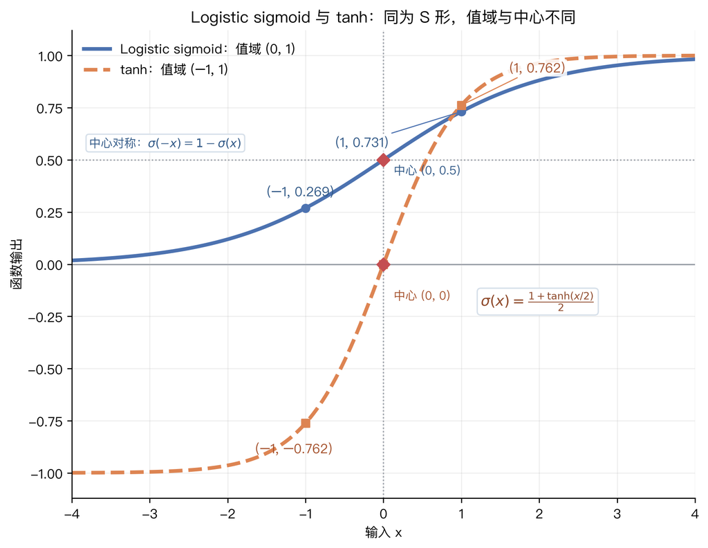

```python
# 在同一坐标轴比较两种 S 形函数的值域、对称中心和 x=±1 时的函数值。
z_compare = np.linspace(-4, 4, 401)
sigmoid_compare = 1 / (1 + np.exp(-z_compare))
tanh_compare = np.tanh(z_compare)

fig, ax = plt.subplots(figsize=(7.4, 5.7), constrained_layout=True)
ax.plot(z_compare, sigmoid_compare, color="#4C72B0", linewidth=2.8, label="Logistic sigmoid：值域 (0, 1)")
ax.plot(z_compare, tanh_compare, color="#DD8452", linewidth=2.8, linestyle="--", label="tanh：值域 (−1, 1)")
ax.axhline(0, color="#9299A3", linewidth=1, zorder=0)
ax.axhline(0.5, color="#9299A3", linestyle=":", linewidth=1, zorder=0)
ax.axvline(0, color="#9299A3", linestyle=":", linewidth=1, zorder=0)

sigmoid_points = 1 / (1 + np.exp(-np.array([-1, 0, 1])))
tanh_points = np.tanh([-1, 0, 1])
ax.scatter([-1, 0, 1], sigmoid_points, color="#4C72B0", s=36, zorder=3)
ax.scatter([-1, 0, 1], tanh_points, color="#DD8452", marker="s", s=34, zorder=3)
ax.scatter([0, 0], [0.5, 0], marker="D", s=48, color="#C44E52", zorder=4)
ax.annotate("(−1, 0.269)", (-1, sigmoid_points[0]), xytext=(-4, 9), textcoords="offset points", ha="center", color="#315987")
ax.annotate("(−1, −0.762)", (-1, tanh_points[0]), xytext=(-9, -23), textcoords="offset points", ha="center", color="#A6532E")
label_box = {"boxstyle": "round,pad=0.15", "facecolor": "white", "edgecolor": "none", "alpha": 0.88}
ax.annotate("(1, 0.731)", (1, sigmoid_points[2]), xytext=(-76, -27), textcoords="offset points", ha="center", color="#315987", bbox=label_box, arrowprops={"arrowstyle": "-", "color": "#4C72B0", "lw": 0.8})
ax.annotate("(1, 0.762)", (1, tanh_points[2]), xytext=(58, 25), textcoords="offset points", ha="center", color="#A6532E", bbox=label_box, arrowprops={"arrowstyle": "-", "color": "#DD8452", "lw": 0.8})
ax.text(0.13, 0.43, "中心 (0, 0.5)", color="#315987", fontsize=9)
ax.text(0.13, -0.17, "中心 (0, 0)", color="#A6532E", fontsize=9)
formula_box = {"boxstyle": "round,pad=0.25", "facecolor": "white", "edgecolor": "#D5DFE9", "alpha": 0.94}
ax.text(-3.78, 0.56, r"中心对称：$\sigma(-x)=1-\sigma(x)$", color="#315987", fontsize=9, bbox=formula_box)
ax.text(1.25, -0.20, r"$\sigma(x)=\frac{1+\tanh(x/2)}{2}$", color="#8F4A2B", fontsize=11, bbox=formula_box)
ax.set(title="Logistic sigmoid 与 tanh：同为 S 形，值域与中心不同", xlabel="输入 x", ylabel="函数输出", xlim=(-4, 4), ylim=(-1.12, 1.12))
ax.legend(loc="upper left", frameon=False)
ax.grid(alpha=0.2)
ax.spines[["top", "right"]].set_visible(False)

asset_dir.mkdir(parents=True, exist_ok=True)
fig.savefig(asset_dir / "lab04-sigmoid-tanh.png", dpi=180, bbox_inches="tight", facecolor="white")
plt.show()
```

## 可选附录｜单特征探索（不影响主实验）

下面保留备课时的候选特征实验，课堂可跳过。它们不参与前面八特征模型的训练、阈值选择或最终测试。所有评价仍使用验证集。

### A.1｜比较四个连续候选特征

每次只取一列，分别训练两个模型。这里**没有**设置类别平衡权重（`class_weight`），保留原始类别比例；不把单特征探索当作算法排名。

```python
candidate_features = ["BILL_AMT1", "BILL_AMT2", "PAY_AMT1", "PAY_AMT2"]
continuous_results = []
continuous_models = {}
```

### A.2｜逐个训练

循环只重复模型建立和训练；每个缩放器仍只在训练集拟合。

```python
for feature in candidate_features:
    x_train, x_valid = X_fit[[feature]], X_valid[[feature]]
    regression_model = make_pipeline(StandardScaler(), LinearRegression())
    svc_model = make_pipeline(StandardScaler(), LinearSVC(C=1.0, dual=False, max_iter=5000, random_state=42))
    regression_model.fit(x_train, y_fit)
    svc_model.fit(x_train, y_fit)
    continuous_models[feature] = (regression_model, svc_model)
```

### A.2（续）｜记录验证指标

训练完成后再预测和评分。以下计算重复第 3 节，不使用最终测试集。

```python
for feature in candidate_features:
    x_valid = X_valid[[feature]]
    regression_model, svc_model = continuous_models[feature]
    # 在同一验证集预测；不使用最终测试集。
    reg_output = regression_model.predict(x_valid)
    reg_class = (reg_output >= .5).astype(int)
    svc_class = svc_model.predict(x_valid)
    reg_error = np.mean(reg_class != y_valid.to_numpy())
    svc_error = np.mean(svc_class != y_valid.to_numpy())
    reg_recall = np.mean(reg_class[y_valid.to_numpy() == 1] == 1)
    svc_recall = np.mean(svc_class[y_valid.to_numpy() == 1] == 1)
    # 保存指标和模型，绘图不用重新训练。
    continuous_results.append((feature, reg_error, reg_recall, svc_error, svc_recall,
                               reg_output.min(), reg_output.max()))
```

### A.3｜查看指标表

召回率为 0 表示没有找回实际违约客户；它不等于错误率为 0。

```python
display(pd.DataFrame(continuous_results, columns=["特征", "回归错误率", "回归召回率", "SVC错误率", "SVC召回率", "回归输出最小值", "回归输出最大值"]))
```

|  | 特征 | 回归错误率 | 回归召回率 | SVC错误率 | SVC召回率 | 回归输出最小值 | 回归输出最大值 |
| --- | --- | --- | --- | --- | --- | --- | --- |
| 0 | BILL_AMT1 | 0.221167 | 0.0 | 0.221167 | 0.0 | 0.096439 | 0.229149 |
| 1 | BILL_AMT2 | 0.221167 | 0.0 | 0.221167 | 0.0 | 0.119505 | 0.233848 |
| 2 | PAY_AMT1 | 0.221167 | 0.0 | 0.221167 | 0.0 | -0.246130 | 0.231060 |
| 3 | PAY_AMT2 | 0.221167 | 0.0 | 0.221167 | 0.0 | -1.188552 | 0.229342 |

### A.4｜候选特征图（辅助绘图）

仅为避免极端值挤压图形，横轴使用**训练集**的 1%–99% 分位范围；指标仍按整个验证集计算。缩小显示范围不代表删除训练或评价样本。

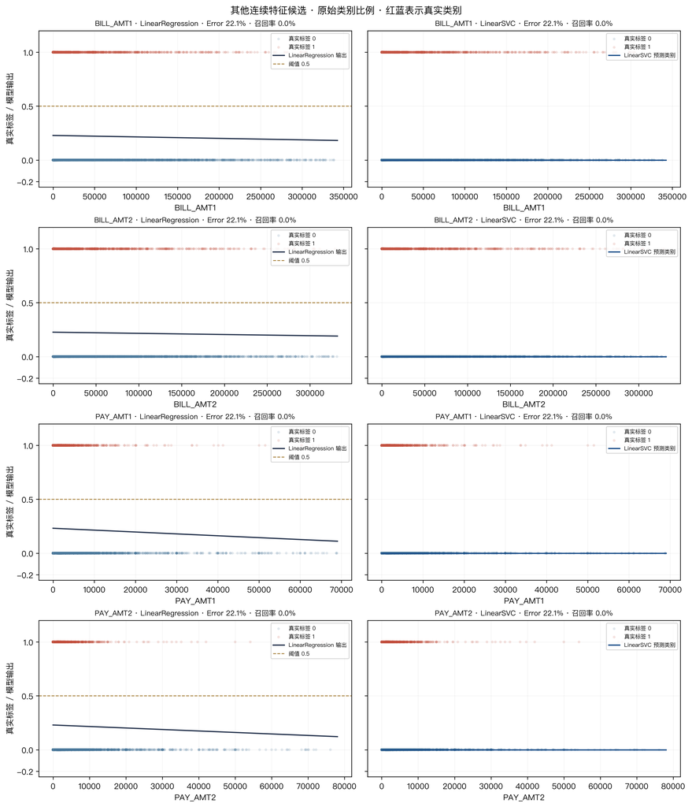

```python
fig, axes = plt.subplots(len(candidate_features), 2, figsize=(12, 3.5 * len(candidate_features)), sharey=True, layout="constrained")
for row, feature in enumerate(candidate_features):
    x_valid = X_valid[[feature]]
    regression_model, svc_model = continuous_models[feature]
    _, reg_error, reg_recall, svc_error, svc_recall, _, _ = continuous_results[row]
    low, high = X_fit[feature].quantile([.01, .99])
    visible = x_valid[feature].between(low, high)
    x_curve = np.linspace(low, high, 400)
    x_frame = pd.DataFrame({feature: x_curve})
    reg_curve = regression_model.predict(x_frame)
    svc_curve = svc_model.predict(x_frame)
    for col, ax in enumerate(axes[row]):
        for label, color, name in [(0, "#46769A", "真实标签 0"), (1, "#C34B39", "真实标签 1")]:
            mask = (y_valid.to_numpy() == label) & visible.to_numpy()
            ax.scatter(x_valid.loc[mask, feature], y_valid.to_numpy()[mask], s=11, alpha=.16,
                       color=color, edgecolors="none", label=name)
        ax.set_ylim(-.25, 1.2)
        ax.set_yticks([-.2, 0, .5, 1])
        ax.grid(alpha=.12)
        ax.set_xlabel(feature)
        if col == 0:
            ax.plot(x_curve, reg_curve, color="#25334D", lw=1.5, label="LinearRegression 输出")
            ax.axhline(.5, color="#A27A32", ls="--", lw=1, label="阈值 0.5")
            ax.set_title(f"{feature} · LinearRegression · Error {reg_error:.1%} · 召回率 {reg_recall:.1%}", fontsize=9)
            ax.set_ylabel("真实标签 / 模型输出")
        else:
            ax.step(x_curve, svc_curve, where="mid", color="#174B87", lw=1.5, label="LinearSVC 预测类别")
            ax.set_title(f"{feature} · LinearSVC · Error {svc_error:.1%} · 召回率 {svc_recall:.1%}", fontsize=9)
        ax.legend(loc="upper right", fontsize=7)
fig.suptitle("其他连续特征候选 · 原始类别比例 · 红蓝表示真实类别", fontsize=12)
fig.savefig(asset_dir / "lab04-continuous-feature-comparison.png", dpi=180, facecolor="white")
plt.show()
```

### B.1｜还款状态与二次特征

`PAY_0` 是离散的最近还款状态。`PolynomialFeatures(degree=2)` 将输入扩展为 `PAY_0` 和 `PAY_0²`，再训练 Logistic 回归；SVC 只用原始特征。

**特征表示不同，不能把结果差异完全归因于算法。**这不是前面的八特征主模型。

**模型结构：**Logistic 分支是还款状态 → 一次项和平方项 → 标准化 → Logistic 回归；SVC 分支是还款状态 → 标准化 → 线性 SVC。下面直接保存两条流水线的文本结构，无需展开交互式模型图。

```python
from sklearn.preprocessing import PolynomialFeatures
discrete_feature = ["PAY_0"]
discrete_logistic = make_pipeline(
    PolynomialFeatures(degree=2, include_bias=False), StandardScaler(),
    LogisticRegression(max_iter=2000, random_state=42))
discrete_svc = make_pipeline(
    StandardScaler(), LinearSVC(C=1.0, dual=False, max_iter=5000, random_state=42))
discrete_logistic.fit(X_fit[discrete_feature], y_fit)
discrete_svc.fit(X_fit[discrete_feature], y_fit)

print("二次特征概率模型：", discrete_logistic)
print("原始特征分类模型：", discrete_svc)
```

```
二次特征概率模型： Pipeline(steps=[('polynomialfeatures', PolynomialFeatures(include_bias=False)),
                ('standardscaler', StandardScaler()),
                ('logisticregression',
                 LogisticRegression(max_iter=2000, random_state=42))])
原始特征分类模型： Pipeline(steps=[('standardscaler', StandardScaler()),
                ('linearsvc',
                 LinearSVC(dual=False, max_iter=5000, random_state=42))])
```

### B.2｜在验证集评价

仍用错误率和违约召回率，不查看最终测试集；概率转类别采用模型默认决策规则。

```python
discrete_pred = [discrete_logistic.predict(X_valid[discrete_feature]),
                 discrete_svc.predict(X_valid[discrete_feature])]
discrete_error = [np.mean(pred != y_valid.to_numpy()) for pred in discrete_pred]
discrete_recall = [np.mean(pred[y_valid.to_numpy() == 1] == 1) for pred in discrete_pred]
print(f"二次 Logistic：错误率 {discrete_error[0]:.2%}；违约召回率 {discrete_recall[0]:.2%}")
print(f"LinearSVC：错误率 {discrete_error[1]:.2%}；违约召回率 {discrete_recall[1]:.2%}")
```

```
二次 Logistic：错误率 18.40%；违约召回率 31.35%
LinearSVC：错误率 21.67%；违约召回率 4.37%
```

### B.3｜查看每个还款状态的输出

上面的指标基于全部验证客户；这里的表只展示模型在各个离散取值上的输出。

```python
levels = np.sort(X_cls["PAY_0"].unique())
discrete_grid = pd.DataFrame({"PAY_0": levels})
discrete_prob = discrete_logistic.predict_proba(discrete_grid)[:, 1]
discrete_class = discrete_svc.predict(discrete_grid)
print(f"PAY_0 取值：{levels.tolist()}")

display(discrete_grid.assign(Logistic违约概率=discrete_prob, SVC预测类别=discrete_class))
```

```
PAY_0 取值：[-2, -1, 0, 1, 2, 3, 4, 5, 6, 7, 8]
```

|  | PAY_0 | Logistic违约概率 | SVC预测类别 |
| --- | --- | --- | --- |
| 0 | -2 | 0.114649 | 0 |
| 1 | -1 | 0.117629 | 0 |
| 2 | 0 | 0.168078 | 0 |
| 3 | 1 | 0.310705 | 0 |
| 4 | 2 | 0.596858 | 0 |
| 5 | 3 | 0.877432 | 1 |
| 6 | 4 | 0.980754 | 1 |
| 7 | 5 | 0.998131 | 1 |
| 8 | 6 | 0.999879 | 1 |
| 9 | 7 | 0.999995 | 1 |
| 10 | 8 | 1.000000 | 1 |

### B.4｜还款状态对照图（辅助绘图）

横向抖动只为减少散点重叠，不改变模型输入。上图是概率，下图是类别，不能把两种输出当成相同的量。

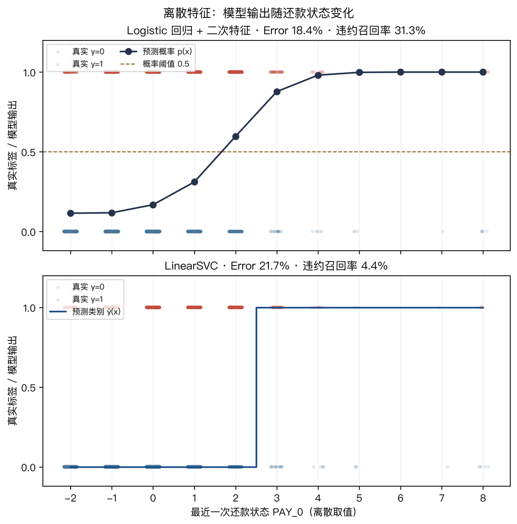

```python
fig, axes = plt.subplots(2, 1, figsize=(7.1, 7.2), sharex=True, sharey=True, layout="constrained")
rng = np.random.default_rng(42)
x_observed = X_valid["PAY_0"].to_numpy()
y_observed = y_valid.to_numpy()
for ax in axes:
    jitter = rng.uniform(-.16, .16, len(x_observed))
    for label, color, name in [(0, "#46769A", "真实 y=0"), (1, "#C34B39", "真实 y=1")]:
        mask = y_observed == label
        ax.scatter(x_observed[mask]+jitter[mask], y_observed[mask], s=12, alpha=.14,
                   color=color, edgecolors="none", label=name)
    ax.set_ylim(-.12, 1.2)
    ax.set_yticks([0, .5, 1])
    ax.set_ylabel("真实标签 / 模型输出")
    ax.grid(axis="x", alpha=.15)
axes[0].plot(levels, discrete_prob, color="#25334D", marker="o", lw=1.6,
             label="预测概率 p(x)", zorder=5)
axes[0].axhline(.5, color="#8A6A2C", ls="--", lw=1, label="概率阈值 0.5")
axes[0].set_title(f"Logistic 回归 + 二次特征 · Error {discrete_error[0]:.1%} · 违约召回率 {discrete_recall[0]:.1%}", fontsize=11)
axes[0].legend(loc="upper left", fontsize=8, ncol=2)
axes[1].step(levels, discrete_class, where="mid", color="#174B87", lw=1.6,
             label="预测类别 ŷ(x)", zorder=5)
axes[1].set_title(f"LinearSVC · Error {discrete_error[1]:.1%} · 违约召回率 {discrete_recall[1]:.1%}", fontsize=11)
axes[1].set_xlabel("最近一次还款状态 PAY_0（离散取值）")
axes[1].set_xticks(levels)
axes[1].legend(loc="upper left", fontsize=8)
fig.suptitle("离散特征：模型输出随还款状态变化", fontsize=12)
fig.savefig(asset_dir / "lab04-discrete-feature-comparison.png", dpi=200, facecolor="white")
plt.show()
```

**选做**：若要更公平地比较算法，可让两种模型使用同样的特征变换，再比较验证结果。若要研究二次特征的作用，可固定 Logistic 回归，只改变是否添加平方项。

## 可选附录｜上游十模型全景图

课堂不要求逐行读巨幅绘图。完整上游计算和BSD署名保留在辅助源码的`official_comparison`，包含三数据集×十模型训练。GaussianProcessClassifier仍使用既有optimizer=None适配。设置下面开关为True才运行；它与前面复核任务独立。

```python
RUN_OFFICIAL_APPENDIX = False
if RUN_OFFICIAL_APPENDIX:
    # 可选官方附录需使用课程提供的 helpers/，主线不依赖此文件。
    import sys
    sys.path.insert(0, str(notebook_dir))
    from helpers.step_early import official_comparison, export_comparison_assets
    official_comparison()
```

## 教师可选｜导出旧课件素材

此操作会覆盖lessons/assets下既有lab03指标与三幅图；默认不写文件。训练主线指标不依赖此导出。

```python
EXPORT_LESSON_ASSETS = False
if EXPORT_LESSON_ASSETS:
    import sys
    sys.path.insert(0, str(notebook_dir))
    from helpers.step_early import export_comparison_assets
    export_comparison_assets(chosen, threshold_table, y_final, final_pred)
```